# Gesture Recognition

#### Developed by:

##### 1. Ashai Reddy

### Problem Statement

Imagine you are working as a data scientist at a home electronics company which manufactures state of the art smart televisions. You want to develop a cool feature in the smart-TV that can recognise five different gestures performed by the user which will help users control the TV without using a remote.

The gestures are continuously monitored by the webcam mounted on the TV. Each gesture corresponds to a specific command:

| Gesture | Corresponding Action |
| --- | --- |
| Thumbs Up | Increase the volume. |
| Thumbs Down | Decrease the volume. |
| Left Swipe | 'Jump' backwards 10 seconds. |
| Right Swipe | 'Jump' forward 10 seconds. |
| Stop | Pause the movie. |

Each video is a sequence of 30 frames (or images).

### Objectives:

1. **Generator**: The generator should be able to take a batch of videos as input without any error. Steps like cropping, resizing and normalization should be performed successfully.
2. **Model**: Develop a model that is able to train without any errors which will be judged on the total number of parameters (as the inference(prediction) time should be less) and the accuracy achieved. As suggested by Snehansu, start training on a small amount of data and then proceed further.
3. **Write up**: This should contain the detailed procedure followed in choosing the final model. The write up should start with the reason for choosing the base model, then highlight the reasons and metrics taken into consideration to modify and experiment to arrive at the final model.

## Importing Packages

```python
import numpy as np
import os
from imageio import imread
from skimage.transform import resize
import datetime
import os
import datetime
import matplotlib.pyplot as plt
from tensorflow.keras import backend as K
import tensorflow as tf
import random as rn
import cv2
```

We set the random seed so that the results don't vary drastically.

### Note: We are using Tensorflow 2.4.0, so code is changed accordingly according to newer versions of packages

```python
def reset_random_seeds():
   os.environ['PYTHONHASHSEED']=str(30)
   tf.random.set_seed(30)
   np.random.seed(30)
   rn.seed(30)
```

In this block, you read the folder names for training and validation. You also set the `batch_size` here. Note that you set the batch size in such a way that you are able to use the GPU in full capacity. You keep increasing the batch size until the machine throws an error.

```python
!nvidia-smi
```

[output not shown]

```python
train_doc = np.random.permutation(open('./Project_data/train.csv').readlines())
val_doc = np.random.permutation(open('./Project_data/val.csv').readlines())
batch_size = 30 #experiment with the batch size
```

## Generator

This is one of the most important part of the code. The overall structure of the generator has been given. In the generator, you are going to preprocess the images as you have images of 2 different dimensions as well as create a batch of video frames. You have to experiment with `img_idx`, `y`,`z` and normalization such that you get high accuracy.

```python
image_x_shape = 100
image_y_shape = 100
```

```python
def generator(source_path, folder_list, batch_size, augment=False):
    print( 'Source path = ', source_path, '; batch size =', batch_size)
    img_idx = list(range(0, 30, 3)) #create a list of image numbers you want to use for a particular video
    x, y, z = len(img_idx), image_x_shape, image_y_shape
    while True:
        t = np.random.permutation(folder_list)
        total_folders = len(folder_list)
        num_batches = total_folders // batch_size #<TODO># calculate the number of batches
        for batch in range(num_batches): # we iterate over the number of batches

            batch_data = np.zeros((batch_size,x,y,z,3)) # x is the number of images you use for each video, (y,z) is the final size of the input images and 3 is the number of channels RGB
            batch_labels = np.zeros((batch_size,5)) # batch_labels is the one hot representation of the output

            if augment:
                batch_data_aug = np.zeros((batch_size,x,y,z,3))

            for folder in range(batch_size): # iterate over the batch_size
                imgs = os.listdir(source_path+'/'+ t[folder + (batch*batch_size)].split(';')[0]) # read all the images in the folder
                for idx,item in enumerate(img_idx): #  Iterate iver the frames/images of a folder to read them in
                    image = imread(source_path+'/'+ t[folder + (batch*batch_size)].strip().split(';')[0]+'/'+imgs[item]).astype(np.float32)

                    #crop the images and resize them. Note that the images are of 2 different shape
                    resizedImage = resize(image, (y, z),anti_aliasing=True)
                    #and the conv3D will throw error if the inputs in a batch have different shapes

                    ### Normalize the data
                    resizedImage = resizedImage / 255
                    ###

                    ### Standardise the Data
                    batch_data[folder,idx,:,:,0] = (resizedImage[:, :, 0] - resizedImage[:, :, 0].mean()) / resizedImage[:, :, 0].std() #normalise and feed in the image
                    batch_data[folder,idx,:,:,1] = (resizedImage[:, :, 1] - resizedImage[:, :, 1].mean()) / resizedImage[:, :, 1].std()
                    batch_data[folder,idx,:,:,2] = (resizedImage[:, :, 2] - resizedImage[:, :, 2].mean()) / resizedImage[:, :, 2].std()
                    ###

                    ### Data Augmentation
                    if augment:

                        shifted = cv2.warpAffine(image,np.float32([[1, 0, np.random.randint(-30,30)],[0, 1, np.random.randint(-30,30)]]),(image.shape[1], image.shape[0]))
                        gray = cv2.cvtColor(shifted,cv2.COLOR_BGR2GRAY)
                        x0, y0 = np.argwhere(gray > 0).min(axis=0)
                        x1, y1 = np.argwhere(gray > 0).max(axis=0)
                        # cropping the images to have the targeted gestures and remove the noise from the images.
                        cropped=shifted[x0:x1,y0:y1,:]
                        image_resized=resize(cropped,(y, z),anti_aliasing=True)

                        ### Normalize the data
                        resizedImage = image_resized / 255
                        ###

                        ### Standardise the Data
                        batch_data_aug[folder,idx,:,:,0] = (resizedImage[:, :, 0] - resizedImage[:, :, 0].mean()) / resizedImage[:, :, 0].std() #normalise and feed in the image
                        batch_data_aug[folder,idx,:,:,1] = (resizedImage[:, :, 1] - resizedImage[:, :, 1].mean()) / resizedImage[:, :, 1].std()
                        batch_data_aug[folder,idx,:,:,2] = (resizedImage[:, :, 2] - resizedImage[:, :, 2].mean()) / resizedImage[:, :, 2].std()
                        ###


                batch_labels[folder, int(t[folder + (batch*batch_size)].strip().split(';')[2])] = 1

            if (augment):
                batch_data=np.concatenate([batch_data,batch_data_aug])
                batch_labels=np.concatenate([batch_labels,batch_labels])

            yield batch_data, batch_labels #you yield the batch_data and the batch_labels, remember what does yield do

        # write the code for the remaining data points which are left after full batches
        missing_count = total_folders - (num_batches * batch_size)
        if missing_count != 0:
            batch_data = np.zeros((missing_count,x,y,z,3))
            batch_labels = np.zeros((missing_count,5))

            if augment:
                batch_data_aug2 = np.zeros((missing_count,x,y,z,3))

            for folder in range(missing_count):
                imgs = os.listdir(source_path+'/'+ t[folder + (batch*batch_size)].split(';')[0]) # read all the images in the folder
                for idx,item in enumerate(img_idx): #  Iterate iver the frames/images of a folder to read them in
                    image = imread(source_path+'/'+ t[folder + (batch*batch_size)].strip().split(';')[0]+'/'+imgs[item]).astype(np.float32)

                    #crop the images and resize them. Note that the images are of 2 different shape
                    resizedImage = resize(image, (y, z),anti_aliasing=True)
                    #and the conv3D will throw error if the inputs in a batch have different shapes

                    ### Normalize the data
                    resizedImage = resizedImage / 255
                    ###

                    ### Standardise the Data
                    batch_data[folder,idx,:,:,0] = (resizedImage[:, :, 0] - resizedImage[:, :, 0].mean()) / resizedImage[:, :, 0].std() #normalise and feed in the image
                    batch_data[folder,idx,:,:,1] = (resizedImage[:, :, 1] - resizedImage[:, :, 1].mean()) / resizedImage[:, :, 1].std()
                    batch_data[folder,idx,:,:,2] = (resizedImage[:, :, 2] - resizedImage[:, :, 2].mean()) / resizedImage[:, :, 2].std()
                    ###

                    if augment:

                        shifted = cv2.warpAffine(image,np.float32([[1, 0, np.random.randint(-30,30)],[0, 1, np.random.randint(-30,30)]]),(image.shape[1], image.shape[0]))
                        gray = cv2.cvtColor(shifted,cv2.COLOR_BGR2GRAY)
                        x0, y0 = np.argwhere(gray > 0).min(axis=0)
                        x1, y1 = np.argwhere(gray > 0).max(axis=0)
                        # cropping the images to have the targeted gestures and remove the noise from the images.
                        cropped=shifted[x0:x1,y0:y1,:]
                        image_resized=resize(cropped,(y, z),anti_aliasing=True)

                        ### Normalize the data
                        resizedImage = image_resized / 255
                        ###

                        ### Standardise the Data
                        batch_data_aug2[folder,idx,:,:,0] = (resizedImage[:, :, 0] - resizedImage[:, :, 0].mean()) / resizedImage[:, :, 0].std() #normalise and feed in the image
                        batch_data_aug2[folder,idx,:,:,1] = (resizedImage[:, :, 1] - resizedImage[:, :, 1].mean()) / resizedImage[:, :, 1].std()
                        batch_data_aug2[folder,idx,:,:,2] = (resizedImage[:, :, 2] - resizedImage[:, :, 2].mean()) / resizedImage[:, :, 2].std()
                        ###


                batch_labels[folder, int(t[folder + (batch*batch_size)].strip().split(';')[2])] = 1


            if (augment):
                batch_data=np.concatenate([batch_data,batch_data_aug2])
                batch_labels=np.concatenate([batch_labels,batch_labels])

        yield batch_data, batch_labels
```

Note here that a video is represented above in the generator as (number of images, height, width, number of channels). Take this into consideration while creating the model architecture.

```python
curr_dt_time = datetime.datetime.now()
train_path = './Project_data/train'
val_path = './Project_data/val'
num_train_sequences = len(train_doc)
print('# training sequences =', num_train_sequences)
num_val_sequences = len(val_doc)
print('# validation sequences =', num_val_sequences)
num_epochs = 30 # choose the number of epochs
print ('# epochs =', num_epochs)
```

```
# training sequences = 663
# validation sequences = 100
# epochs = 30
```

# Modelling

## Model 1: Conv2D + LSTM

Here you make the model using different functionalities that Keras provides. Remember to use `Conv3D` and `MaxPooling3D` and not `Conv2D` and `Maxpooling2D` for a 3D convolution model. You would want to use `TimeDistributed` while building a Conv2D + RNN model. Also remember that the last layer is the softmax. Design the network in such a way that the model is able to give good accuracy on the least number of parameters so that it can fit in the memory of the webcam.

```python
from tensorflow.keras.models import Sequential, Model
from sklearn.metrics import roc_auc_score
from tensorflow.keras.layers import Dense, GRU, LSTM, Flatten, TimeDistributed, Flatten, BatchNormalization, Activation, Conv2D, Dropout
from tensorflow.keras.layers import Conv3D, MaxPooling3D, MaxPooling2D
from tensorflow.keras.callbacks import ModelCheckpoint, ReduceLROnPlateau, EarlyStopping
from tensorflow.keras import optimizers, regularizers
from tensorflow.keras.regularizers import l2
import tensorflow.keras
```

Now that you have written the model, the next step is to `compile` the model. When you print the `summary` of the model, you'll see the total number of parameters you have to train.

```python
class Convolution2DWithLSTM():
    def __init__(self):
        return None

    def model(self, batch_size):
        cnn_model = Sequential()
        cnn_model.add(TimeDistributed(Conv2D(32, (1, 1), padding='same'), input_shape=(10, image_x_shape, image_y_shape, 3)))
        cnn_model.add(TimeDistributed(Activation('relu')))
        cnn_model.add(TimeDistributed(MaxPooling2D((3, 3), strides = (2,2))))
        cnn_model.add(TimeDistributed(BatchNormalization()))

        cnn_model.add(TimeDistributed(Conv2D(32, (3, 3), padding='same')))
        cnn_model.add(TimeDistributed(Activation('relu')))
        cnn_model.add(TimeDistributed(MaxPooling2D((3, 3), strides = (2,2))))
        cnn_model.add(TimeDistributed(BatchNormalization()))

        cnn_model.add(TimeDistributed(Conv2D(64, (3, 3), padding='same', kernel_regularizer=l2(0.01), bias_regularizer=l2(0.01))))
        cnn_model.add(TimeDistributed(Activation('relu')))
        cnn_model.add(TimeDistributed(BatchNormalization()))
        cnn_model.add(Dropout(0.25))

        cnn_model.add(TimeDistributed(Conv2D(64, (3, 3), padding='same', kernel_regularizer=l2(0.01), bias_regularizer=l2(0.01))))
        cnn_model.add(TimeDistributed(Activation('relu')))


        cnn_model.add(TimeDistributed(MaxPooling2D((3, 3))))

        cnn_model.add(TimeDistributed(Conv2D(64, (3, 3), padding='same')))
        cnn_model.add(TimeDistributed(Activation('relu')))

        cnn_model.add(Dropout(0.25))

        cnn_model.add(TimeDistributed(Conv2D(128, (3, 3), padding='same', kernel_regularizer=l2(0.01), bias_regularizer=l2(0.01))))
        cnn_model.add(TimeDistributed(Activation('relu')))

        cnn_model.add(Dropout(0.50))

        cnn_model.add(TimeDistributed(Conv2D(256, (5, 5), padding='same', kernel_regularizer=l2(0.01), bias_regularizer=l2(0.01))))
        cnn_model.add(TimeDistributed(Activation('relu')))


        cnn_model.add(TimeDistributed(Flatten()))
        cnn_model.add(LSTM(64, return_sequences=False))
        cnn_model.add(Dropout(.2))
        cnn_model.add(Dense(5, activation='softmax'))
        return cnn_model
```

```python
reduceLR = ReduceLROnPlateau(monitor = "val_loss", factor = 0.5, patience = 2,
                             verbose = 1, mode = "auto", cooldown = 0)
```

```python
class DecayLR(tensorflow.keras.callbacks.Callback):

    def __init__(self, base_lr=0.01, decay_epoch=1):
        super(DecayLR, self).__init__()
        self.base_lr = base_lr
        self.lr_history = []
        self.decay_epoch = decay_epoch

    def on_train_begin(self, logs={}):
        K.set_value(self.model.optimizer.lr, self.base_lr)

    def on_epoch_end(self, epoch, logs={}):
        new_lr = self.base_lr * (0.5 ** (epoch // self.decay_epoch))
        self.lr_history.append(K.get_value(self.model.optimizer.lr))
        K.set_value(self.model.optimizer.lr, new_lr)
```

```python
reset_random_seeds()
obj = Convolution2DWithLSTM()
model = obj.model(batch_size)
optimiser = optimizers.SGD()

model.compile(optimizer=optimiser, loss='categorical_crossentropy', metrics=['accuracy'])
print (model.summary())
```

```
Model: "sequential"
_________________________________________________________________
Layer (type)                 Output Shape              Param #
=================================================================
time_distributed (TimeDistri (None, 10, 100, 100, 32)  128
_________________________________________________________________
time_distributed_1 (TimeDist (None, 10, 100, 100, 32)  0
_________________________________________________________________
time_distributed_2 (TimeDist (None, 10, 49, 49, 32)    0
_________________________________________________________________
time_distributed_3 (TimeDist (None, 10, 49, 49, 32)    128
_________________________________________________________________
time_distributed_4 (TimeDist (None, 10, 49, 49, 32)    9248
_________________________________________________________________
time_distributed_5 (TimeDist (None, 10, 49, 49, 32)    0
_________________________________________________________________
time_distributed_6 (TimeDist (None, 10, 24, 24, 32)    0
_________________________________________________________________
time_distributed_7 (TimeDist (None, 10, 24, 24, 32)    128
_________________________________________________________________
time_distributed_8 (TimeDist (None, 10, 24, 24, 64)    18496
_________________________________________________________________
time_distributed_9 (TimeDist (None, 10, 24, 24, 64)    0
_________________________________________________________________
time_distributed_10 (TimeDis (None, 10, 24, 24, 64)    256
_________________________________________________________________
dropout (Dropout)            (None, 10, 24, 24, 64)    0
_________________________________________________________________
time_distributed_11 (TimeDis (None, 10, 24, 24, 64)    36928
_________________________________________________________________
time_distributed_12 (TimeDis (None, 10, 24, 24, 64)    0
_________________________________________________________________
time_distributed_13 (TimeDis (None, 10, 8, 8, 64)      0
_________________________________________________________________
time_distributed_14 (TimeDis (None, 10, 8, 8, 64)      36928
_________________________________________________________________
time_distributed_15 (TimeDis (None, 10, 8, 8, 64)      0
_________________________________________________________________
dropout_1 (Dropout)          (None, 10, 8, 8, 64)      0
_________________________________________________________________
```

[output cut: 8 more lines]

```
time_distributed_19 (TimeDis (None, 10, 8, 8, 256)     0
_________________________________________________________________
time_distributed_20 (TimeDis (None, 10, 16384)         0
_________________________________________________________________
lstm (LSTM)                  (None, 64)                4210944
_________________________________________________________________
dropout_3 (Dropout)          (None, 64)                0
_________________________________________________________________
dense (Dense)                (None, 5)                 325
=================================================================
Total params: 5,206,821
Trainable params: 5,206,565
Non-trainable params: 256
_________________________________________________________________
None
```

Let us create the `train_generator` and the `val_generator` which will be used in `.fit` as we are using tensorflow 2.4.0.

```python
train_generator = generator(train_path, train_doc, batch_size)
val_generator = generator(val_path, val_doc, batch_size)
```

```python
model_name = 'model_init' + '_' + str(curr_dt_time).replace(' ','').replace(':','_') + '/'

if not os.path.exists(model_name):
    os.mkdir(model_name)

early_stopping = EarlyStopping(patience=3)

filepath = model_name + 'model-{epoch:05d}-{loss:.5f}-{accuracy:.5f}-{val_loss:.5f}-{val_accuracy:.5f}.h5'

checkpoint = ModelCheckpoint(filepath, monitor='val_loss', verbose=1, save_best_only=False, save_weights_only=False, mode='auto', period=1)

callbacks_list = [checkpoint,reduceLR]
```

```
WARNING:tensorflow:`period` argument is deprecated. Please use `save_freq` to specify the frequency in number of batches seen.
```

The `steps_per_epoch` and `validation_steps` are used by `fit_generator` to decide the number of next() calls it need to make.

```python
if (num_train_sequences%batch_size) == 0:
    steps_per_epoch = int(num_train_sequences/batch_size)
else:
    steps_per_epoch = (num_train_sequences//batch_size) + 1

if (num_val_sequences%batch_size) == 0:
    validation_steps = int(num_val_sequences/batch_size)
else:
    validation_steps = (num_val_sequences//batch_size) + 1
```

Let us now fit the model. This will start training the model and with the help of the checkpoints, you'll be able to save the model at the end of each epoch.

```python
model_history = model.fit(train_generator, steps_per_epoch=steps_per_epoch, epochs=num_epochs, verbose=1,
                    callbacks=callbacks_list, validation_data=val_generator,
                    validation_steps=validation_steps, class_weight=None, workers=1, initial_epoch=0)
```

```
Source path =  ./Project_data/train ; batch size = 30

Epoch 00001: saving model to model_init_2021-03-0607_15_05.084969/model-00001-5.26629-0.21569-5.19872-0.33000.h5

Epoch 00002: saving model to model_init_2021-03-0607_15_05.084969/model-00002-5.13496-0.27602-5.15853-0.33000.h5

Epoch 00003: saving model to model_init_2021-03-0607_15_05.084969/model-00003-5.04153-0.36802-5.09893-0.18000.h5

Epoch 00004: saving model to model_init_2021-03-0607_15_05.084969/model-00004-4.89500-0.40724-5.00055-0.44000.h5

Epoch 00005: saving model to model_init_2021-03-0607_15_05.084969/model-00005-4.71362-0.52338-4.96241-0.31000.h5

Epoch 00006: saving model to model_init_2021-03-0607_15_05.084969/model-00006-4.54688-0.58069-4.81090-0.42000.h5

Epoch 00007: saving model to model_init_2021-03-0607_15_05.084969/model-00007-4.47598-0.59125-4.91249-0.26000.h5

Epoch 00008: saving model to model_init_2021-03-0607_15_05.084969/model-00008-4.43843-0.58824-4.74727-0.42000.h5

Epoch 00009: saving model to model_init_2021-03-0607_15_05.084969/model-00009-4.31571-0.62745-4.68976-0.40000.h5

Epoch 00010: saving model to model_init_2021-03-0607_15_05.084969/model-00010-4.25370-0.63198-4.68474-0.41000.h5

Epoch 00011: saving model to model_init_2021-03-0607_15_05.084969/model-00011-4.15000-0.67722-4.29630-0.64000.h5

Epoch 00012: saving model to model_init_2021-03-0607_15_05.084969/model-00012-4.09900-0.66214-5.25816-0.32000.h5

Epoch 00013: saving model to model_init_2021-03-0607_15_05.084969/model-00013-4.25159-0.61388-4.38114-0.57000.h5

Epoch 00013: ReduceLROnPlateau reducing learning rate to 0.004999999888241291.

Epoch 00014: saving model to model_init_2021-03-0607_15_05.084969/model-00014-4.03000-0.68778-4.18486-0.62000.h5

Epoch 00015: saving model to model_init_2021-03-0607_15_05.084969/model-00015-3.87264-0.75867-4.14293-0.65000.h5

Epoch 00016: saving model to model_init_2021-03-0607_15_05.084969/model-00016-3.82485-0.75867-4.07584-0.69000.h5

Epoch 00017: saving model to model_init_2021-03-0607_15_05.084969/model-00017-3.79749-0.78130-4.13651-0.62000.h5

Epoch 00018: saving model to model_init_2021-03-0607_15_05.084969/model-00018-3.76134-0.78582-4.11916-0.61000.h5

```

[output cut: 14 more lines]

```
Epoch 00025: saving model to model_init_2021-03-0607_15_05.084969/model-00025-3.54751-0.85370-4.09731-0.63000.h5

Epoch 00025: ReduceLROnPlateau reducing learning rate to 0.0012499999720603228.

Epoch 00026: saving model to model_init_2021-03-0607_15_05.084969/model-00026-3.53362-0.85671-3.98482-0.66000.h5

Epoch 00027: saving model to model_init_2021-03-0607_15_05.084969/model-00027-3.49784-0.87330-3.85450-0.76000.h5

Epoch 00028: saving model to model_init_2021-03-0607_15_05.084969/model-00028-3.48908-0.86727-3.79224-0.77000.h5

Epoch 00029: saving model to model_init_2021-03-0607_15_05.084969/model-00029-3.44245-0.88084-3.92670-0.65000.h5

Epoch 00030: saving model to model_init_2021-03-0607_15_05.084969/model-00030-3.43653-0.88235-3.84225-0.71000.h5

Epoch 00030: ReduceLROnPlateau reducing learning rate to 0.0006249999860301614.
```

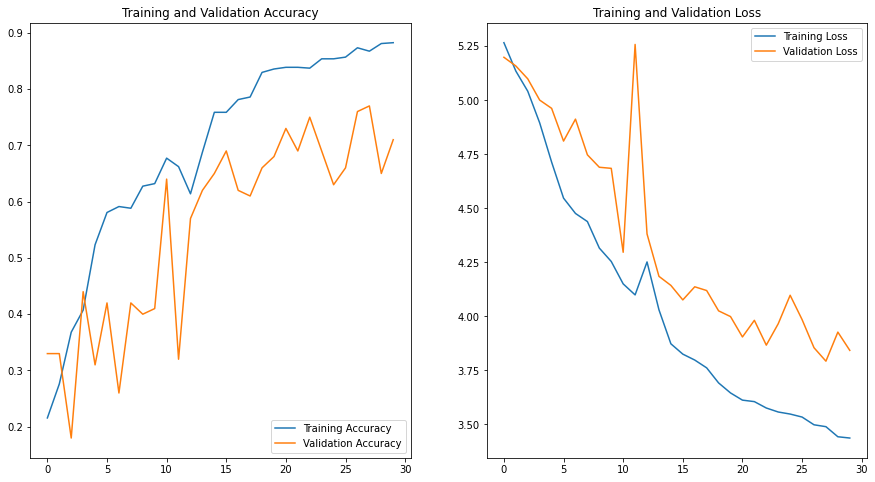

```python
history = model_history
acc = history.history['accuracy']
val_acc = history.history['val_accuracy']

loss = history.history['loss']
val_loss = history.history['val_loss']

epochs_range = range(num_epochs)

plt.figure(figsize=(15, 8))
plt.subplot(1, 2, 1)
plt.plot(epochs_range, acc, label='Training Accuracy')
plt.plot(epochs_range, val_acc, label='Validation Accuracy')
plt.legend(loc='lower right')
plt.title('Training and Validation Accuracy')

plt.subplot(1, 2, 2)
plt.plot(epochs_range, loss, label='Training Loss')
plt.plot(epochs_range, val_loss, label='Validation Loss')
plt.legend(loc='upper right')
plt.title('Training and Validation Loss')
plt.show()
```

## Model 2: Conv2D + GRU

- Replace LSTM with GRU will reduce parameters
- Parameters reduced from 5 Million --> 4 Million

```python
batch_size=30
num_epochs=30
reset_random_seeds()

class Convolution2DWithGRU():
    def __init__(self):
        return None

    def model(self, batch_size):
        cnn_model = Sequential()
        cnn_model.add(TimeDistributed(Conv2D(32, (1, 1), padding='same'), input_shape=(10, image_x_shape, image_y_shape, 3)))
        cnn_model.add(TimeDistributed(Activation('relu')))
        cnn_model.add(TimeDistributed(MaxPooling2D((3, 3), strides = (2,2))))
        cnn_model.add(TimeDistributed(BatchNormalization()))

        cnn_model.add(TimeDistributed(Conv2D(32, (3, 3), padding='same')))
        cnn_model.add(TimeDistributed(Activation('relu')))
        cnn_model.add(TimeDistributed(MaxPooling2D((3, 3), strides = (2,2))))
        cnn_model.add(TimeDistributed(BatchNormalization()))

        cnn_model.add(TimeDistributed(Conv2D(64, (3, 3), padding='same', kernel_regularizer=l2(0.01), bias_regularizer=l2(0.01))))
        cnn_model.add(TimeDistributed(Activation('relu')))
        cnn_model.add(TimeDistributed(BatchNormalization()))
        cnn_model.add(Dropout(0.25))

        cnn_model.add(TimeDistributed(Conv2D(64, (3, 3), padding='same', kernel_regularizer=l2(0.01), bias_regularizer=l2(0.01))))
        cnn_model.add(TimeDistributed(Activation('relu')))


        cnn_model.add(TimeDistributed(MaxPooling2D((3, 3))))

        cnn_model.add(TimeDistributed(Conv2D(64, (3, 3), padding='same')))
        cnn_model.add(TimeDistributed(Activation('relu')))

        cnn_model.add(Dropout(0.25))

        cnn_model.add(TimeDistributed(Conv2D(128, (3, 3), padding='same', kernel_regularizer=l2(0.01), bias_regularizer=l2(0.01))))
        cnn_model.add(TimeDistributed(Activation('relu')))

        cnn_model.add(Dropout(0.50))

        cnn_model.add(TimeDistributed(Conv2D(256, (5, 5), padding='same', kernel_regularizer=l2(0.01), bias_regularizer=l2(0.01))))
        cnn_model.add(TimeDistributed(Activation('relu')))


        cnn_model.add(TimeDistributed(Flatten()))
        cnn_model.add(GRU(64, return_sequences=False))
        cnn_model.add(Dropout(.2))
        cnn_model.add(Dense(5, activation='softmax'))
        return cnn_model

obj = Convolution2DWithGRU()
model = obj.model(batch_size)
optimiser = optimizers.SGD()

model.compile(optimizer=optimiser, loss='categorical_crossentropy', metrics=['accuracy'])
print (model.summary())

train_generator = generator(train_path, train_doc, batch_size)
val_generator = generator(val_path, val_doc, batch_size)

model_name = 'model_init' + '_' + str(curr_dt_time).replace(' ','').replace(':','_') + '/'

if not os.path.exists(model_name):
    os.mkdir(model_name)

early_stopping = EarlyStopping(patience=3)

filepath = model_name + 'model-{epoch:05d}-{loss:.5f}-{accuracy:.5f}-{val_loss:.5f}-{val_accuracy:.5f}.h5'

checkpoint = ModelCheckpoint(filepath, monitor='val_loss', verbose=1, save_best_only=False, save_weights_only=False, mode='auto', period=1)

callbacks_list = [checkpoint,reduceLR]

if (num_train_sequences%batch_size) == 0:
    steps_per_epoch = int(num_train_sequences/batch_size)
else:
    steps_per_epoch = (num_train_sequences//batch_size) + 1

if (num_val_sequences%batch_size) == 0:
    validation_steps = int(num_val_sequences/batch_size)
else:
    validation_steps = (num_val_sequences//batch_size) + 1

model_history_gru = model.fit(train_generator, steps_per_epoch=steps_per_epoch, epochs=num_epochs, verbose=1,
                    callbacks=callbacks_list, validation_data=val_generator,
                    validation_steps=validation_steps, class_weight=None, workers=1, initial_epoch=0)
```

```
Model: "sequential_1"
_________________________________________________________________
Layer (type)                 Output Shape              Param #
=================================================================
time_distributed_21 (TimeDis (None, 10, 100, 100, 32)  128
_________________________________________________________________
time_distributed_22 (TimeDis (None, 10, 100, 100, 32)  0
_________________________________________________________________
time_distributed_23 (TimeDis (None, 10, 49, 49, 32)    0
_________________________________________________________________
time_distributed_24 (TimeDis (None, 10, 49, 49, 32)    128
_________________________________________________________________
time_distributed_25 (TimeDis (None, 10, 49, 49, 32)    9248
_________________________________________________________________
time_distributed_26 (TimeDis (None, 10, 49, 49, 32)    0
_________________________________________________________________
time_distributed_27 (TimeDis (None, 10, 24, 24, 32)    0
_________________________________________________________________
time_distributed_28 (TimeDis (None, 10, 24, 24, 32)    128
_________________________________________________________________
time_distributed_29 (TimeDis (None, 10, 24, 24, 64)    18496
_________________________________________________________________
time_distributed_30 (TimeDis (None, 10, 24, 24, 64)    0
_________________________________________________________________
time_distributed_31 (TimeDis (None, 10, 24, 24, 64)    256
_________________________________________________________________
dropout_4 (Dropout)          (None, 10, 24, 24, 64)    0
_________________________________________________________________
time_distributed_32 (TimeDis (None, 10, 24, 24, 64)    36928
_________________________________________________________________
time_distributed_33 (TimeDis (None, 10, 24, 24, 64)    0
_________________________________________________________________
time_distributed_34 (TimeDis (None, 10, 8, 8, 64)      0
_________________________________________________________________
time_distributed_35 (TimeDis (None, 10, 8, 8, 64)      36928
_________________________________________________________________
time_distributed_36 (TimeDis (None, 10, 8, 8, 64)      0
_________________________________________________________________
dropout_5 (Dropout)          (None, 10, 8, 8, 64)      0
_________________________________________________________________
```

[output cut: 84 more lines]

```
Epoch 00025: ReduceLROnPlateau reducing learning rate to 0.0003124999930150807.

Epoch 00026: saving model to model_init_2021-03-0607_15_05.084969/model-00026-3.59289-0.85520-3.96984-0.67000.h5

Epoch 00027: saving model to model_init_2021-03-0607_15_05.084969/model-00027-3.59272-0.86124-3.94556-0.70000.h5

Epoch 00027: ReduceLROnPlateau reducing learning rate to 0.00015624999650754035.

Epoch 00028: saving model to model_init_2021-03-0607_15_05.084969/model-00028-3.59466-0.85520-3.85460-0.75000.h5

Epoch 00029: saving model to model_init_2021-03-0607_15_05.084969/model-00029-3.56789-0.85671-3.97943-0.70000.h5

Epoch 00030: saving model to model_init_2021-03-0607_15_05.084969/model-00030-3.57530-0.87330-3.90452-0.77000.h5

Epoch 00030: ReduceLROnPlateau reducing learning rate to 7.812499825377017e-05.
```

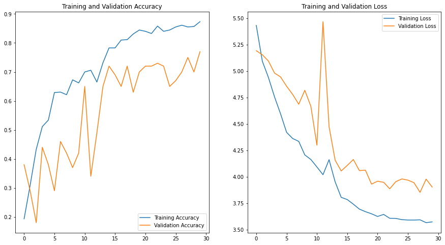

```python
history = model_history_gru
acc = history.history['accuracy']
val_acc = history.history['val_accuracy']

loss = history.history['loss']
val_loss = history.history['val_loss']

epochs_range = range(num_epochs)

plt.figure(figsize=(15, 8))
plt.subplot(1, 2, 1)
plt.plot(epochs_range, acc, label='Training Accuracy')
plt.plot(epochs_range, val_acc, label='Validation Accuracy')
plt.legend(loc='lower right')
plt.title('Training and Validation Accuracy')

plt.subplot(1, 2, 2)
plt.plot(epochs_range, loss, label='Training Loss')
plt.plot(epochs_range, val_loss, label='Validation Loss')
plt.legend(loc='upper right')
plt.title('Training and Validation Loss')
plt.show()
```

### Insights

- Model Parameters reduced from **4 Million --> 1 Million**
- Number of Epochs are increased from **30 --> 50**

```python
batch_size=30
num_epochs=50
reset_random_seeds()

class Convolution2DWithGRU():
    def __init__(self):
        return None

    def model(self, batch_size):
        cnn_model = Sequential()
        cnn_model.add(TimeDistributed(Conv2D(32, (1, 1), padding='same'), input_shape=(10, image_x_shape, image_y_shape, 3)))
        cnn_model.add(TimeDistributed(Activation('relu')))
        cnn_model.add(TimeDistributed(MaxPooling2D((3, 3), strides = (2,2))))
        cnn_model.add(TimeDistributed(BatchNormalization()))

        cnn_model.add(TimeDistributed(Conv2D(32, (3, 3), padding='same')))
        cnn_model.add(TimeDistributed(Activation('relu')))
        cnn_model.add(TimeDistributed(MaxPooling2D((3, 3), strides = (2,2))))
        cnn_model.add(TimeDistributed(BatchNormalization()))

        cnn_model.add(TimeDistributed(Conv2D(64, (3, 3), padding='same', kernel_regularizer=l2(0.01), bias_regularizer=l2(0.01))))
        cnn_model.add(TimeDistributed(Activation('relu')))
        cnn_model.add(TimeDistributed(BatchNormalization()))
        cnn_model.add(Dropout(0.25))

        cnn_model.add(TimeDistributed(Conv2D(64, (3, 3), padding='same', kernel_regularizer=l2(0.01), bias_regularizer=l2(0.01))))
        cnn_model.add(TimeDistributed(Activation('relu')))


        cnn_model.add(TimeDistributed(MaxPooling2D((3, 3))))

        cnn_model.add(TimeDistributed(Conv2D(64, (3, 3), padding='same')))
        cnn_model.add(TimeDistributed(Activation('relu')))

        cnn_model.add(Dropout(0.25))

        cnn_model.add(TimeDistributed(Conv2D(128, (3, 3), padding='same', kernel_regularizer=l2(0.01), bias_regularizer=l2(0.01))))
        cnn_model.add(TimeDistributed(Activation('relu')))

        cnn_model.add(Dropout(0.50))

        cnn_model.add(TimeDistributed(Conv2D(256, (5, 5), padding='same', kernel_regularizer=l2(0.01), bias_regularizer=l2(0.01))))
        cnn_model.add(TimeDistributed(Activation('relu')))


        cnn_model.add(TimeDistributed(Flatten()))
        cnn_model.add(Dense(16, activation='relu'))
        cnn_model.add(Dropout(.2))
        cnn_model.add(GRU(64, return_sequences=False))
        cnn_model.add(Dropout(.2))
        cnn_model.add(Dense(5, activation='softmax'))
        return cnn_model

obj = Convolution2DWithGRU()
model = obj.model(batch_size)
optimiser = optimizers.SGD() #write your optimizer

model.compile(optimizer=optimiser, loss='categorical_crossentropy', metrics=['accuracy'])
print (model.summary())

train_generator = generator(train_path, train_doc, batch_size)
val_generator = generator(val_path, val_doc, batch_size)

model_name = 'model_init' + '_' + str(curr_dt_time).replace(' ','').replace(':','_') + '/'

if not os.path.exists(model_name):
    os.mkdir(model_name)

early_stopping = EarlyStopping(patience=3)

filepath = model_name + 'model-{epoch:05d}-{loss:.5f}-{accuracy:.5f}-{val_loss:.5f}-{val_accuracy:.5f}.h5'

checkpoint = ModelCheckpoint(filepath, monitor='val_loss', verbose=1, save_best_only=False, save_weights_only=False, mode='auto', period=1)

callbacks_list = [checkpoint,reduceLR]

if (num_train_sequences%batch_size) == 0:
    steps_per_epoch = int(num_train_sequences/batch_size)
else:
    steps_per_epoch = (num_train_sequences//batch_size) + 1

if (num_val_sequences%batch_size) == 0:
    validation_steps = int(num_val_sequences/batch_size)
else:
    validation_steps = (num_val_sequences//batch_size) + 1

model_history_epoch50 = model.fit(train_generator, steps_per_epoch=steps_per_epoch, epochs=num_epochs, verbose=1,
                    callbacks=callbacks_list, validation_data=val_generator,
                    validation_steps=validation_steps, class_weight=None, workers=1, initial_epoch=0)
```

```
Model: "sequential_2"
_________________________________________________________________
Layer (type)                 Output Shape              Param #
=================================================================
time_distributed_42 (TimeDis (None, 10, 100, 100, 32)  128
_________________________________________________________________
time_distributed_43 (TimeDis (None, 10, 100, 100, 32)  0
_________________________________________________________________
time_distributed_44 (TimeDis (None, 10, 49, 49, 32)    0
_________________________________________________________________
time_distributed_45 (TimeDis (None, 10, 49, 49, 32)    128
_________________________________________________________________
time_distributed_46 (TimeDis (None, 10, 49, 49, 32)    9248
_________________________________________________________________
time_distributed_47 (TimeDis (None, 10, 49, 49, 32)    0
_________________________________________________________________
time_distributed_48 (TimeDis (None, 10, 24, 24, 32)    0
_________________________________________________________________
time_distributed_49 (TimeDis (None, 10, 24, 24, 32)    128
_________________________________________________________________
time_distributed_50 (TimeDis (None, 10, 24, 24, 64)    18496
_________________________________________________________________
time_distributed_51 (TimeDis (None, 10, 24, 24, 64)    0
_________________________________________________________________
time_distributed_52 (TimeDis (None, 10, 24, 24, 64)    256
_________________________________________________________________
dropout_8 (Dropout)          (None, 10, 24, 24, 64)    0
_________________________________________________________________
time_distributed_53 (TimeDis (None, 10, 24, 24, 64)    36928
_________________________________________________________________
time_distributed_54 (TimeDis (None, 10, 24, 24, 64)    0
_________________________________________________________________
time_distributed_55 (TimeDis (None, 10, 8, 8, 64)      0
_________________________________________________________________
time_distributed_56 (TimeDis (None, 10, 8, 8, 64)      36928
_________________________________________________________________
time_distributed_57 (TimeDis (None, 10, 8, 8, 64)      0
_________________________________________________________________
dropout_9 (Dropout)          (None, 10, 8, 8, 64)      0
_________________________________________________________________
```

[output cut: 138 more lines]

```
Epoch 00046: saving model to model_init_2021-03-0607_15_05.084969/model-00046-3.95527-0.68175-4.03107-0.63000.h5

Epoch 00046: ReduceLROnPlateau reducing learning rate to 9.765624781721272e-06.

Epoch 00047: saving model to model_init_2021-03-0607_15_05.084969/model-00047-3.95412-0.66214-3.98925-0.64000.h5

Epoch 00048: saving model to model_init_2021-03-0607_15_05.084969/model-00048-3.93173-0.68477-4.07223-0.58000.h5

Epoch 00048: ReduceLROnPlateau reducing learning rate to 4.882812390860636e-06.

Epoch 00049: saving model to model_init_2021-03-0607_15_05.084969/model-00049-3.95749-0.66365-4.01376-0.60000.h5

Epoch 00050: saving model to model_init_2021-03-0607_15_05.084969/model-00050-3.96460-0.68477-4.12520-0.58000.h5

Epoch 00050: ReduceLROnPlateau reducing learning rate to 2.441406195430318e-06.
```

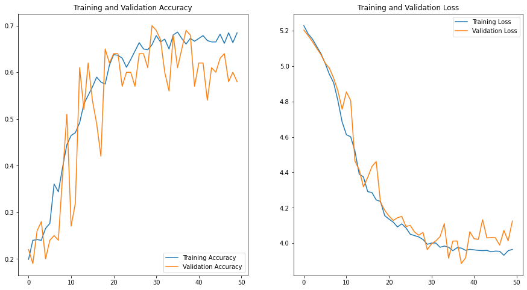

```python
history = model_history_epoch50
acc = history.history['accuracy']
val_acc = history.history['val_accuracy']

loss = history.history['loss']
val_loss = history.history['val_loss']

epochs_range = range(num_epochs)

plt.figure(figsize=(15, 8))
plt.subplot(1, 2, 1)
plt.plot(epochs_range, acc, label='Training Accuracy')
plt.plot(epochs_range, val_acc, label='Validation Accuracy')
plt.legend(loc='lower right')
plt.title('Training and Validation Accuracy')

plt.subplot(1, 2, 2)
plt.plot(epochs_range, loss, label='Training Loss')
plt.plot(epochs_range, val_loss, label='Validation Loss')
plt.legend(loc='upper right')
plt.title('Training and Validation Loss')
plt.show()
```

## Model 4: Conv2D + GRU (Epochs = 40, Batch Size = 60)

```python
batch_size=60
num_epochs=40
reset_random_seeds()

class Convolution2DWithGRU():
    def __init__(self):
        return None

    def model(self, batch_size):
        cnn_model = Sequential()
        cnn_model.add(TimeDistributed(Conv2D(32, (1, 1), padding='same'), input_shape=(10, image_x_shape, image_y_shape, 3)))
        cnn_model.add(TimeDistributed(Activation('relu')))
        cnn_model.add(TimeDistributed(MaxPooling2D((3, 3), strides = (2,2))))
        cnn_model.add(TimeDistributed(BatchNormalization()))

        cnn_model.add(TimeDistributed(Conv2D(32, (3, 3), padding='same')))
        cnn_model.add(TimeDistributed(Activation('relu')))
        cnn_model.add(TimeDistributed(MaxPooling2D((3, 3), strides = (2,2))))
        cnn_model.add(TimeDistributed(BatchNormalization()))

        cnn_model.add(TimeDistributed(Conv2D(64, (3, 3), padding='same', kernel_regularizer=l2(0.01), bias_regularizer=l2(0.01))))
        cnn_model.add(TimeDistributed(Activation('relu')))
        cnn_model.add(TimeDistributed(BatchNormalization()))
        cnn_model.add(Dropout(0.25))

        cnn_model.add(TimeDistributed(Conv2D(64, (3, 3), padding='same', kernel_regularizer=l2(0.01), bias_regularizer=l2(0.01))))
        cnn_model.add(TimeDistributed(Activation('relu')))


        cnn_model.add(TimeDistributed(MaxPooling2D((3, 3))))

        cnn_model.add(TimeDistributed(Conv2D(64, (3, 3), padding='same')))
        cnn_model.add(TimeDistributed(Activation('relu')))

        cnn_model.add(Dropout(0.25))

        cnn_model.add(TimeDistributed(Conv2D(128, (3, 3), padding='same', kernel_regularizer=l2(0.01), bias_regularizer=l2(0.01))))
        cnn_model.add(TimeDistributed(Activation('relu')))

        cnn_model.add(Dropout(0.50))

        cnn_model.add(TimeDistributed(Conv2D(256, (5, 5), padding='same', kernel_regularizer=l2(0.01), bias_regularizer=l2(0.01))))
        cnn_model.add(TimeDistributed(Activation('relu')))


        cnn_model.add(TimeDistributed(Flatten()))
        cnn_model.add(Dense(16, activation='relu'))
        cnn_model.add(Dropout(.2))
        cnn_model.add(GRU(64, return_sequences=False))
        cnn_model.add(Dropout(.2))
        cnn_model.add(Dense(5, activation='softmax'))
        return cnn_model

obj = Convolution2DWithGRU()
model = obj.model(batch_size)
optimiser = optimizers.SGD() #write your optimizer

model.compile(optimizer=optimiser, loss='categorical_crossentropy', metrics=['accuracy'])
print (model.summary())

train_generator = generator(train_path, train_doc, batch_size)
val_generator = generator(val_path, val_doc, batch_size)

model_name = 'model_init' + '_' + str(curr_dt_time).replace(' ','').replace(':','_') + '/'

if not os.path.exists(model_name):
    os.mkdir(model_name)

early_stopping = EarlyStopping(patience=3)

filepath = model_name + 'model-{epoch:05d}-{loss:.5f}-{accuracy:.5f}-{val_loss:.5f}-{val_accuracy:.5f}.h5'

checkpoint = ModelCheckpoint(filepath, monitor='val_loss', verbose=1, save_best_only=False, save_weights_only=False, mode='auto', period=1)

callbacks_list = [checkpoint,reduceLR]

if (num_train_sequences%batch_size) == 0:
    steps_per_epoch = int(num_train_sequences/batch_size)
else:
    steps_per_epoch = (num_train_sequences//batch_size) + 1

if (num_val_sequences%batch_size) == 0:
    validation_steps = int(num_val_sequences/batch_size)
else:
    validation_steps = (num_val_sequences//batch_size) + 1

model_history_btsize60 = model.fit(train_generator, steps_per_epoch=steps_per_epoch, epochs=num_epochs, verbose=1,
                    callbacks=callbacks_list, validation_data=val_generator,
                    validation_steps=validation_steps, class_weight=None, workers=1, initial_epoch=0)
```

```
Model: "sequential_3"
_________________________________________________________________
Layer (type)                 Output Shape              Param #
=================================================================
time_distributed_63 (TimeDis (None, 10, 100, 100, 32)  128
_________________________________________________________________
time_distributed_64 (TimeDis (None, 10, 100, 100, 32)  0
_________________________________________________________________
time_distributed_65 (TimeDis (None, 10, 49, 49, 32)    0
_________________________________________________________________
time_distributed_66 (TimeDis (None, 10, 49, 49, 32)    128
_________________________________________________________________
time_distributed_67 (TimeDis (None, 10, 49, 49, 32)    9248
_________________________________________________________________
time_distributed_68 (TimeDis (None, 10, 49, 49, 32)    0
_________________________________________________________________
time_distributed_69 (TimeDis (None, 10, 24, 24, 32)    0
_________________________________________________________________
time_distributed_70 (TimeDis (None, 10, 24, 24, 32)    128
_________________________________________________________________
time_distributed_71 (TimeDis (None, 10, 24, 24, 64)    18496
_________________________________________________________________
time_distributed_72 (TimeDis (None, 10, 24, 24, 64)    0
_________________________________________________________________
time_distributed_73 (TimeDis (None, 10, 24, 24, 64)    256
_________________________________________________________________
dropout_13 (Dropout)         (None, 10, 24, 24, 64)    0
_________________________________________________________________
time_distributed_74 (TimeDis (None, 10, 24, 24, 64)    36928
_________________________________________________________________
time_distributed_75 (TimeDis (None, 10, 24, 24, 64)    0
_________________________________________________________________
time_distributed_76 (TimeDis (None, 10, 8, 8, 64)      0
_________________________________________________________________
time_distributed_77 (TimeDis (None, 10, 8, 8, 64)      36928
_________________________________________________________________
time_distributed_78 (TimeDis (None, 10, 8, 8, 64)      0
_________________________________________________________________
dropout_14 (Dropout)         (None, 10, 8, 8, 64)      0
_________________________________________________________________
```

[output cut: 98 more lines]

```
Epoch 00034: ReduceLROnPlateau reducing learning rate to 0.004999999888241291.

Epoch 00035: saving model to model_init_2021-03-0607_15_05.084969/model-00035-4.47419-0.39970-4.54115-0.34000.h5

Epoch 00036: saving model to model_init_2021-03-0607_15_05.084969/model-00036-4.49943-0.38763-4.50999-0.39000.h5

Epoch 00037: saving model to model_init_2021-03-0607_15_05.084969/model-00037-4.44761-0.41176-4.52441-0.33000.h5

Epoch 00038: saving model to model_init_2021-03-0607_15_05.084969/model-00038-4.44660-0.40724-4.56004-0.34000.h5

Epoch 00038: ReduceLROnPlateau reducing learning rate to 0.0024999999441206455.

Epoch 00039: saving model to model_init_2021-03-0607_15_05.084969/model-00039-4.45193-0.41176-4.46091-0.47000.h5

Epoch 00040: saving model to model_init_2021-03-0607_15_05.084969/model-00040-4.39749-0.43288-4.43132-0.44000.h5
```

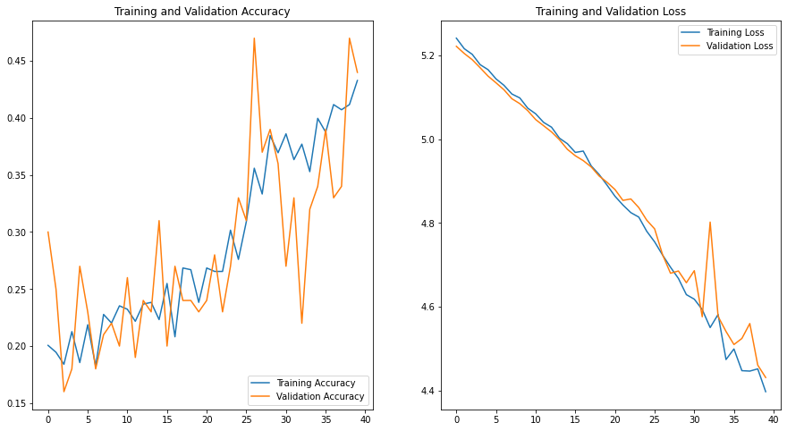

```python
history = model_history_btsize60
acc = history.history['accuracy']
val_acc = history.history['val_accuracy']

loss = history.history['loss']
val_loss = history.history['val_loss']

epochs_range = range(num_epochs)

plt.figure(figsize=(15, 8))
plt.subplot(1, 2, 1)
plt.plot(epochs_range, acc, label='Training Accuracy')
plt.plot(epochs_range, val_acc, label='Validation Accuracy')
plt.legend(loc='lower right')
plt.title('Training and Validation Accuracy')

plt.subplot(1, 2, 2)
plt.plot(epochs_range, loss, label='Training Loss')
plt.plot(epochs_range, val_loss, label='Validation Loss')
plt.legend(loc='upper right')
plt.title('Training and Validation Loss')
plt.show()
```

### Insights:

- Model Learning went slower across all the epochs
- Accuracy decreased significantly
- This might be due to higher batch sizes its effect on gradients
- For now, batch_size=30 seems to be the better model
- Let us try data augmentation on similar settings and see if the model underfit rectifies.

```python
batch_size=60
num_epochs=40
reset_random_seeds()
image_x_shape = 100
image_y_shape = 100

train_generator = generator(train_path, train_doc, batch_size,augment=True)
val_generator = generator(val_path, val_doc, batch_size,augment=True)



class Convolution2DWithGRU():
    def __init__(self):
        return None

    def model(self, batch_size):
        cnn_model = Sequential()
        cnn_model.add(TimeDistributed(Conv2D(32, (1, 1), padding='same'), input_shape=(10, image_x_shape, image_y_shape, 3)))
        cnn_model.add(TimeDistributed(Activation('relu')))
        cnn_model.add(TimeDistributed(MaxPooling2D((3, 3), strides = (2,2))))
        cnn_model.add(TimeDistributed(BatchNormalization()))

        cnn_model.add(TimeDistributed(Conv2D(32, (3, 3), padding='same')))
        cnn_model.add(TimeDistributed(Activation('relu')))
        cnn_model.add(TimeDistributed(MaxPooling2D((3, 3), strides = (2,2))))
        cnn_model.add(TimeDistributed(BatchNormalization()))

        cnn_model.add(TimeDistributed(Conv2D(64, (3, 3), padding='same', kernel_regularizer=l2(0.01), bias_regularizer=l2(0.01))))
        cnn_model.add(TimeDistributed(Activation('relu')))
        cnn_model.add(TimeDistributed(BatchNormalization()))
        cnn_model.add(Dropout(0.25))

        cnn_model.add(TimeDistributed(Conv2D(64, (3, 3), padding='same', kernel_regularizer=l2(0.01), bias_regularizer=l2(0.01))))
        cnn_model.add(TimeDistributed(Activation('relu')))


        cnn_model.add(TimeDistributed(MaxPooling2D((3, 3))))

        cnn_model.add(TimeDistributed(Conv2D(64, (3, 3), padding='same')))
        cnn_model.add(TimeDistributed(Activation('relu')))

        cnn_model.add(Dropout(0.25))

        cnn_model.add(TimeDistributed(Conv2D(128, (3, 3), padding='same', kernel_regularizer=l2(0.01), bias_regularizer=l2(0.01))))
        cnn_model.add(TimeDistributed(Activation('relu')))

        cnn_model.add(Dropout(0.50))

        cnn_model.add(TimeDistributed(Conv2D(256, (5, 5), padding='same', kernel_regularizer=l2(0.01), bias_regularizer=l2(0.01))))
        cnn_model.add(TimeDistributed(Activation('relu')))


        cnn_model.add(TimeDistributed(Flatten()))
        cnn_model.add(Dense(16, activation='relu'))
        cnn_model.add(Dropout(.2))
        cnn_model.add(GRU(64, return_sequences=False))
        cnn_model.add(Dropout(.2))
        cnn_model.add(Dense(5, activation='softmax'))
        return cnn_model

obj = Convolution2DWithGRU()
model = obj.model(batch_size)
optimiser = optimizers.SGD() #write your optimizer

model.compile(optimizer=optimiser, loss='categorical_crossentropy', metrics=['accuracy'])
print (model.summary())

train_generator = generator(train_path, train_doc, batch_size)
val_generator = generator(val_path, val_doc, batch_size)

model_name = 'model_init' + '_' + str(curr_dt_time).replace(' ','').replace(':','_') + '/'

if not os.path.exists(model_name):
    os.mkdir(model_name)

early_stopping = EarlyStopping(patience=3)

filepath = model_name + 'model-{epoch:05d}-{loss:.5f}-{accuracy:.5f}-{val_loss:.5f}-{val_accuracy:.5f}.h5'

checkpoint = ModelCheckpoint(filepath, monitor='val_loss', verbose=1, save_best_only=False, save_weights_only=False, mode='auto', period=1)

callbacks_list = [checkpoint,reduceLR]

if (num_train_sequences%batch_size) == 0:
    steps_per_epoch = int(num_train_sequences/batch_size)
else:
    steps_per_epoch = (num_train_sequences//batch_size) + 1

if (num_val_sequences%batch_size) == 0:
    validation_steps = int(num_val_sequences/batch_size)
else:
    validation_steps = (num_val_sequences//batch_size) + 1

model_history_btsize60_aug = model.fit(train_generator, steps_per_epoch=steps_per_epoch, epochs=num_epochs, verbose=1,
                    callbacks=callbacks_list, validation_data=val_generator,
                    validation_steps=validation_steps, class_weight=None, workers=1, initial_epoch=0)
```

```
Model: "sequential_4"
_________________________________________________________________
Layer (type)                 Output Shape              Param #
=================================================================
time_distributed_84 (TimeDis (None, 10, 100, 100, 32)  128
_________________________________________________________________
time_distributed_85 (TimeDis (None, 10, 100, 100, 32)  0
_________________________________________________________________
time_distributed_86 (TimeDis (None, 10, 49, 49, 32)    0
_________________________________________________________________
time_distributed_87 (TimeDis (None, 10, 49, 49, 32)    128
_________________________________________________________________
time_distributed_88 (TimeDis (None, 10, 49, 49, 32)    9248
_________________________________________________________________
time_distributed_89 (TimeDis (None, 10, 49, 49, 32)    0
_________________________________________________________________
time_distributed_90 (TimeDis (None, 10, 24, 24, 32)    0
_________________________________________________________________
time_distributed_91 (TimeDis (None, 10, 24, 24, 32)    128
_________________________________________________________________
time_distributed_92 (TimeDis (None, 10, 24, 24, 64)    18496
_________________________________________________________________
time_distributed_93 (TimeDis (None, 10, 24, 24, 64)    0
_________________________________________________________________
time_distributed_94 (TimeDis (None, 10, 24, 24, 64)    256
_________________________________________________________________
dropout_18 (Dropout)         (None, 10, 24, 24, 64)    0
_________________________________________________________________
time_distributed_95 (TimeDis (None, 10, 24, 24, 64)    36928
_________________________________________________________________
time_distributed_96 (TimeDis (None, 10, 24, 24, 64)    0
_________________________________________________________________
time_distributed_97 (TimeDis (None, 10, 8, 8, 64)      0
_________________________________________________________________
time_distributed_98 (TimeDis (None, 10, 8, 8, 64)      36928
_________________________________________________________________
time_distributed_99 (TimeDis (None, 10, 8, 8, 64)      0
_________________________________________________________________
dropout_19 (Dropout)         (None, 10, 8, 8, 64)      0
_________________________________________________________________
```

[output cut: 96 more lines]

```
Epoch 00034: saving model to model_init_2021-03-0607_15_05.084969/model-00034-4.52099-0.41478-4.51060-0.35000.h5

Epoch 00035: saving model to model_init_2021-03-0607_15_05.084969/model-00035-4.38218-0.48869-4.49661-0.45000.h5

Epoch 00036: saving model to model_init_2021-03-0607_15_05.084969/model-00036-4.42127-0.48416-4.38634-0.46000.h5

Epoch 00037: saving model to model_init_2021-03-0607_15_05.084969/model-00037-4.30956-0.51433-4.94511-0.24000.h5

Epoch 00038: saving model to model_init_2021-03-0607_15_05.084969/model-00038-4.41740-0.49774-4.50435-0.39000.h5

Epoch 00038: ReduceLROnPlateau reducing learning rate to 0.004999999888241291.

Epoch 00039: saving model to model_init_2021-03-0607_15_05.084969/model-00039-4.35127-0.44646-4.33308-0.53000.h5

Epoch 00040: saving model to model_init_2021-03-0607_15_05.084969/model-00040-4.26493-0.51131-4.30296-0.53000.h5
```

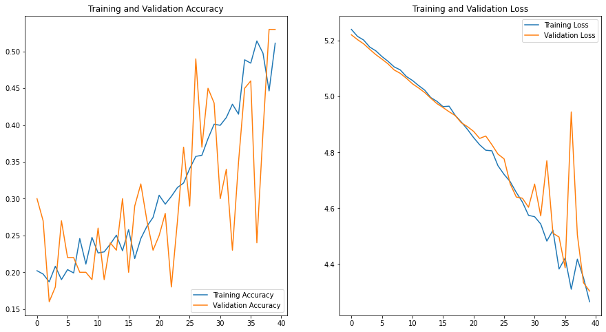

```python
history = model_history_btsize60_aug
acc = history.history['accuracy']
val_acc = history.history['val_accuracy']

loss = history.history['loss']
val_loss = history.history['val_loss']

epochs_range = range(num_epochs)

plt.figure(figsize=(15, 8))
plt.subplot(1, 2, 1)
plt.plot(epochs_range, acc, label='Training Accuracy')
plt.plot(epochs_range, val_acc, label='Validation Accuracy')
plt.legend(loc='lower right')
plt.title('Training and Validation Accuracy')

plt.subplot(1, 2, 2)
plt.plot(epochs_range, loss, label='Training Loss')
plt.plot(epochs_range, val_loss, label='Validation Loss')
plt.legend(loc='upper right')
plt.title('Training and Validation Loss')
plt.show()
```

### Insights:

```python
batch_size=60
num_epochs=40
reset_random_seeds()
image_x_shape = 160
image_y_shape = 160

train_generator = generator(train_path, train_doc, batch_size,augment=True)
val_generator = generator(val_path, val_doc, batch_size,augment=True)


class Convolution2DWithGRU():
    def __init__(self):
        return None

    def model(self, batch_size):
        cnn_model = Sequential()
        cnn_model.add(TimeDistributed(Conv2D(32, (1, 1), padding='same'), input_shape=(10, image_x_shape, image_y_shape, 3)))
        cnn_model.add(TimeDistributed(Activation('relu')))
        cnn_model.add(TimeDistributed(MaxPooling2D((3, 3), strides = (2,2))))
        cnn_model.add(TimeDistributed(BatchNormalization()))

        cnn_model.add(TimeDistributed(Conv2D(32, (3, 3), padding='same')))
        cnn_model.add(TimeDistributed(Activation('relu')))
        cnn_model.add(TimeDistributed(MaxPooling2D((3, 3), strides = (2,2))))
        cnn_model.add(TimeDistributed(BatchNormalization()))

        cnn_model.add(TimeDistributed(Conv2D(64, (3, 3), padding='same', kernel_regularizer=l2(0.01), bias_regularizer=l2(0.01))))
        cnn_model.add(TimeDistributed(Activation('relu')))
        cnn_model.add(TimeDistributed(BatchNormalization()))
        cnn_model.add(Dropout(0.25))

        cnn_model.add(TimeDistributed(Conv2D(64, (3, 3), padding='same', kernel_regularizer=l2(0.01), bias_regularizer=l2(0.01))))
        cnn_model.add(TimeDistributed(Activation('relu')))


        cnn_model.add(TimeDistributed(MaxPooling2D((3, 3))))

        cnn_model.add(TimeDistributed(Conv2D(64, (3, 3), padding='same')))
        cnn_model.add(TimeDistributed(Activation('relu')))

        cnn_model.add(Dropout(0.25))

        cnn_model.add(TimeDistributed(Conv2D(128, (3, 3), padding='same', kernel_regularizer=l2(0.01), bias_regularizer=l2(0.01))))
        cnn_model.add(TimeDistributed(Activation('relu')))

        cnn_model.add(Dropout(0.50))

        cnn_model.add(TimeDistributed(Conv2D(256, (5, 5), padding='same', kernel_regularizer=l2(0.01), bias_regularizer=l2(0.01))))
        cnn_model.add(TimeDistributed(Activation('relu')))


        cnn_model.add(TimeDistributed(Flatten()))
        cnn_model.add(Dense(16, activation='relu'))
        cnn_model.add(Dropout(.2))
        cnn_model.add(GRU(64, return_sequences=False))
        cnn_model.add(Dropout(.2))
        cnn_model.add(Dense(5, activation='softmax'))
        return cnn_model

obj = Convolution2DWithGRU()
model = obj.model(batch_size)
optimiser = optimizers.SGD() #write your optimizer

model.compile(optimizer=optimiser, loss='categorical_crossentropy', metrics=['accuracy'])
print (model.summary())

train_generator = generator(train_path, train_doc, batch_size)
val_generator = generator(val_path, val_doc, batch_size)

model_name = 'model_init' + '_' + str(curr_dt_time).replace(' ','').replace(':','_') + '/'

if not os.path.exists(model_name):
    os.mkdir(model_name)

early_stopping = EarlyStopping(patience=3)

filepath = model_name + 'model-{epoch:05d}-{loss:.5f}-{accuracy:.5f}-{val_loss:.5f}-{val_accuracy:.5f}.h5'

checkpoint = ModelCheckpoint(filepath, monitor='val_loss', verbose=1, save_best_only=False, save_weights_only=False, mode='auto', period=1)

callbacks_list = [checkpoint,reduceLR]

if (num_train_sequences%batch_size) == 0:
    steps_per_epoch = int(num_train_sequences/batch_size)
else:
    steps_per_epoch = (num_train_sequences//batch_size) + 1

if (num_val_sequences%batch_size) == 0:
    validation_steps = int(num_val_sequences/batch_size)
else:
    validation_steps = (num_val_sequences//batch_size) + 1

model_history_btsize60_aug_img60 = model.fit(train_generator, steps_per_epoch=steps_per_epoch, epochs=num_epochs, verbose=1,
                    callbacks=callbacks_list, validation_data=val_generator,
                    validation_steps=validation_steps, class_weight=None, workers=1, initial_epoch=0)
```

```
Model: "sequential_5"
_________________________________________________________________
Layer (type)                 Output Shape              Param #
=================================================================
time_distributed_105 (TimeDi (None, 10, 160, 160, 32)  128
_________________________________________________________________
time_distributed_106 (TimeDi (None, 10, 160, 160, 32)  0
_________________________________________________________________
time_distributed_107 (TimeDi (None, 10, 79, 79, 32)    0
_________________________________________________________________
time_distributed_108 (TimeDi (None, 10, 79, 79, 32)    128
_________________________________________________________________
time_distributed_109 (TimeDi (None, 10, 79, 79, 32)    9248
_________________________________________________________________
time_distributed_110 (TimeDi (None, 10, 79, 79, 32)    0
_________________________________________________________________
time_distributed_111 (TimeDi (None, 10, 39, 39, 32)    0
_________________________________________________________________
time_distributed_112 (TimeDi (None, 10, 39, 39, 32)    128
_________________________________________________________________
time_distributed_113 (TimeDi (None, 10, 39, 39, 64)    18496
_________________________________________________________________
time_distributed_114 (TimeDi (None, 10, 39, 39, 64)    0
_________________________________________________________________
time_distributed_115 (TimeDi (None, 10, 39, 39, 64)    256
_________________________________________________________________
dropout_23 (Dropout)         (None, 10, 39, 39, 64)    0
_________________________________________________________________
time_distributed_116 (TimeDi (None, 10, 39, 39, 64)    36928
_________________________________________________________________
time_distributed_117 (TimeDi (None, 10, 39, 39, 64)    0
_________________________________________________________________
time_distributed_118 (TimeDi (None, 10, 13, 13, 64)    0
_________________________________________________________________
time_distributed_119 (TimeDi (None, 10, 13, 13, 64)    36928
_________________________________________________________________
time_distributed_120 (TimeDi (None, 10, 13, 13, 64)    0
_________________________________________________________________
dropout_24 (Dropout)         (None, 10, 13, 13, 64)    0
_________________________________________________________________
```

[output cut: 100 more lines]

```
Epoch 00034: saving model to model_init_2021-03-0607_15_05.084969/model-00034-4.16397-0.60332-4.26461-0.51000.h5

Epoch 00035: saving model to model_init_2021-03-0607_15_05.084969/model-00035-4.11411-0.61689-4.20049-0.55000.h5

Epoch 00036: saving model to model_init_2021-03-0607_15_05.084969/model-00036-4.09780-0.62142-4.20210-0.54000.h5

Epoch 00037: saving model to model_init_2021-03-0607_15_05.084969/model-00037-4.04622-0.65309-4.26482-0.55000.h5

Epoch 00037: ReduceLROnPlateau reducing learning rate to 0.0012499999720603228.

Epoch 00038: saving model to model_init_2021-03-0607_15_05.084969/model-00038-4.08438-0.60633-4.18131-0.62000.h5

Epoch 00039: saving model to model_init_2021-03-0607_15_05.084969/model-00039-4.04646-0.63650-4.10248-0.61000.h5

Epoch 00040: saving model to model_init_2021-03-0607_15_05.084969/model-00040-4.02537-0.65460-4.11425-0.68000.h5
```

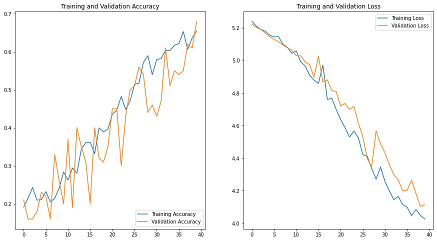

```python
history = model_history_btsize60_aug_img60
acc = history.history['accuracy']
val_acc = history.history['val_accuracy']

loss = history.history['loss']
val_loss = history.history['val_loss']

epochs_range = range(num_epochs)

plt.figure(figsize=(15, 8))
plt.subplot(1, 2, 1)
plt.plot(epochs_range, acc, label='Training Accuracy')
plt.plot(epochs_range, val_acc, label='Validation Accuracy')
plt.legend(loc='lower right')
plt.title('Training and Validation Accuracy')

plt.subplot(1, 2, 2)
plt.plot(epochs_range, loss, label='Training Loss')
plt.plot(epochs_range, val_loss, label='Validation Loss')
plt.legend(loc='upper right')
plt.title('Training and Validation Loss')
plt.show()
```

### Insights:

- Model Learning is having a lot of flucations still
- Improving image size improved accuracy slightly.
- Training Accuracy=64% & Validation Accuracy=68%
- Let us try a different architecture and see how it fares.

## Conv3D Model:

## Model 7: Conv3D + SGD

```python
class convolution3D():
    def __init__(self):
        return None

    def model(self, batch_size):
        model = Sequential()

        model.add(Conv3D(8, kernel_size=(3, 3, 3),activation='relu', padding="same",input_shape=(10, 100, 100, 3)))
        model.add(MaxPooling3D(pool_size=(2, 2, 2)))
        model.add(BatchNormalization())

        model.add(Conv3D(16, kernel_size=(3, 3, 3),activation='relu', padding="same",
                         kernel_regularizer=regularizers.l2(0.01),
                        bias_regularizer=regularizers.l2(0.01)))
        model.add(MaxPooling3D(pool_size=(2, 2, 2)))
        model.add(BatchNormalization())

        model.add(Conv3D(32, kernel_size=(3, 3, 3),activation='relu', padding="same",
                         kernel_regularizer=regularizers.l2(0.01),
                        bias_regularizer=regularizers.l2(0.01)))
        model.add(MaxPooling3D(pool_size=(2, 2, 2)))
        model.add(BatchNormalization())


        model.add(Conv3D(32, kernel_size=(3, 3, 3),activation='relu', padding="same",
                         kernel_regularizer=regularizers.l2(0.01),
                        bias_regularizer=regularizers.l2(0.01)))
        model.add(MaxPooling3D(pool_size=(2, 2, 1),data_format='channels_first'))
        model.add(BatchNormalization())

        model.add(Conv3D(64, kernel_size=(3, 3, 3),activation='relu', padding="same",
                         kernel_regularizer=regularizers.l2(0.01),
                        bias_regularizer=regularizers.l2(0.01)))

        model.add(MaxPooling3D(pool_size=(2, 2, 1),data_format='channels_first'))
        model.add(BatchNormalization())

        model.add(Conv3D(128, kernel_size=(3, 3, 3),activation='relu', padding="same",
                         kernel_regularizer=regularizers.l2(0.01),
                        bias_regularizer=regularizers.l2(0.01)))
        model.add(MaxPooling3D(pool_size=(2, 2, 2),data_format='channels_first'))
        model.add(BatchNormalization())


        model.add(Dropout(0.25))
        model.add(Flatten())
        model.add(Dense(256,activation='relu'))
        model.add(Dropout(0.5))
        model.add(Dense(128,activation='relu'))
        model.add(Dropout(0.5))
        model.add(Dense(64,activation='relu'))
        model.add(Dropout(0.5))
        model.add(Dense(5, activation='softmax'))
        return model
```

```python
reset_random_seeds()
batch_size=30
num_epochs=30
image_x_shape = 100
image_y_shape = 100

train_generator = generator(train_path, train_doc, batch_size,augment=False)
val_generator = generator(val_path, val_doc, batch_size,augment=False)


obj = convolution3D()
conv3d_model = obj.model(batch_size)
conv3d_optimiser = optimizers.SGD() #write your optimizer

conv3d_model.compile(optimizer=conv3d_optimiser, loss='categorical_crossentropy', metrics=['accuracy'])
print (conv3d_model.summary())
```

```
Model: "sequential_6"
_________________________________________________________________
Layer (type)                 Output Shape              Param #
=================================================================
conv3d (Conv3D)              (None, 10, 100, 100, 8)   656
_________________________________________________________________
max_pooling3d (MaxPooling3D) (None, 5, 50, 50, 8)      0
_________________________________________________________________
batch_normalization_18 (Batc (None, 5, 50, 50, 8)      32
_________________________________________________________________
conv3d_1 (Conv3D)            (None, 5, 50, 50, 16)     3472
_________________________________________________________________
max_pooling3d_1 (MaxPooling3 (None, 2, 25, 25, 16)     0
_________________________________________________________________
batch_normalization_19 (Batc (None, 2, 25, 25, 16)     64
_________________________________________________________________
conv3d_2 (Conv3D)            (None, 2, 25, 25, 32)     13856
_________________________________________________________________
max_pooling3d_2 (MaxPooling3 (None, 1, 12, 12, 32)     0
_________________________________________________________________
batch_normalization_20 (Batc (None, 1, 12, 12, 32)     128
_________________________________________________________________
conv3d_3 (Conv3D)            (None, 1, 12, 12, 32)     27680
_________________________________________________________________
max_pooling3d_3 (MaxPooling3 (None, 1, 6, 6, 32)       0
_________________________________________________________________
batch_normalization_21 (Batc (None, 1, 6, 6, 32)       128
_________________________________________________________________
conv3d_4 (Conv3D)            (None, 1, 6, 6, 64)       55360
_________________________________________________________________
max_pooling3d_4 (MaxPooling3 (None, 1, 3, 3, 64)       0
_________________________________________________________________
batch_normalization_22 (Batc (None, 1, 3, 3, 64)       256
_________________________________________________________________
conv3d_5 (Conv3D)            (None, 1, 3, 3, 128)      221312
_________________________________________________________________
max_pooling3d_5 (MaxPooling3 (None, 1, 1, 1, 64)       0
_________________________________________________________________
batch_normalization_23 (Batc (None, 1, 1, 1, 64)       256
_________________________________________________________________
```

[output cut: 8 more lines]

```
dense_11 (Dense)             (None, 128)               32896
_________________________________________________________________
dropout_30 (Dropout)         (None, 128)               0
_________________________________________________________________
dense_12 (Dense)             (None, 64)                8256
_________________________________________________________________
dropout_31 (Dropout)         (None, 64)                0
_________________________________________________________________
dense_13 (Dense)             (None, 5)                 325
=================================================================
Total params: 381,317
Trainable params: 380,885
Non-trainable params: 432
_________________________________________________________________
None
```

```python
model_name = 'model_init' + '_' + str(curr_dt_time).replace(' ','').replace(':','_') + '/'

if not os.path.exists(model_name):
    os.mkdir(model_name)

filepath = model_name + 'model_3d-{epoch:05d}-{loss:.5f}-{accuracy:.5f}-{val_loss:.5f}-{val_accuracy:.5f}.h5'

checkpoint = ModelCheckpoint(filepath, monitor='val_loss', verbose=1, save_best_only=False, save_weights_only=False, mode='auto', period=1)

callbacks_list = [reduceLR,checkpoint]

if (num_train_sequences%batch_size) == 0:
    steps_per_epoch = int(num_train_sequences/batch_size)
else:
    steps_per_epoch = (num_train_sequences//batch_size) + 1

if (num_val_sequences%batch_size) == 0:
    validation_steps = int(num_val_sequences/batch_size)
else:
    validation_steps = (num_val_sequences//batch_size) + 1
```

```
WARNING:tensorflow:`period` argument is deprecated. Please use `save_freq` to specify the frequency in number of batches seen.
```

```python
conv3d_model_history = conv3d_model.fit(train_generator,
                                           steps_per_epoch=steps_per_epoch,
                                           epochs=num_epochs,
                                           verbose=1,
                                           callbacks=callbacks_list,
                                           validation_data=val_generator,
                                           validation_steps=validation_steps,
                                           class_weight=None,
                                           workers=1,
                                           initial_epoch=0)
```

```
Source path =  ./Project_data/train ; batch size = 30

Epoch 00001: saving model to model_init_2021-03-0607_15_05.084969/model_3d-00001-3.94165-0.19306-3.54942-0.23000.h5

Epoch 00002: saving model to model_init_2021-03-0607_15_05.084969/model_3d-00002-3.75244-0.20211-3.54416-0.21000.h5

Epoch 00003: saving model to model_init_2021-03-0607_15_05.084969/model_3d-00003-3.73033-0.21267-3.52391-0.37000.h5

Epoch 00004: saving model to model_init_2021-03-0607_15_05.084969/model_3d-00004-3.67652-0.20965-3.51107-0.23000.h5

Epoch 00005: saving model to model_init_2021-03-0607_15_05.084969/model_3d-00005-3.62041-0.22474-3.49004-0.30000.h5

Epoch 00006: saving model to model_init_2021-03-0607_15_05.084969/model_3d-00006-3.60528-0.23680-3.47321-0.23000.h5

Epoch 00007: saving model to model_init_2021-03-0607_15_05.084969/model_3d-00007-3.54815-0.23831-3.46624-0.20000.h5

Epoch 00008: saving model to model_init_2021-03-0607_15_05.084969/model_3d-00008-3.51921-0.25038-3.43538-0.34000.h5

Epoch 00009: saving model to model_init_2021-03-0607_15_05.084969/model_3d-00009-3.49378-0.24887-3.42507-0.34000.h5

Epoch 00010: saving model to model_init_2021-03-0607_15_05.084969/model_3d-00010-3.50619-0.23379-3.39231-0.39000.h5

Epoch 00011: saving model to model_init_2021-03-0607_15_05.084969/model_3d-00011-3.45496-0.25490-3.37183-0.39000.h5

Epoch 00012: saving model to model_init_2021-03-0607_15_05.084969/model_3d-00012-3.43883-0.23982-3.35101-0.39000.h5

Epoch 00013: saving model to model_init_2021-03-0607_15_05.084969/model_3d-00013-3.39926-0.25792-3.31580-0.41000.h5

Epoch 00014: saving model to model_init_2021-03-0607_15_05.084969/model_3d-00014-3.41702-0.26094-3.28437-0.41000.h5

Epoch 00015: saving model to model_init_2021-03-0607_15_05.084969/model_3d-00015-3.31997-0.29713-3.24315-0.43000.h5

Epoch 00016: saving model to model_init_2021-03-0607_15_05.084969/model_3d-00016-3.32245-0.27903-3.25927-0.39000.h5

Epoch 00017: saving model to model_init_2021-03-0607_15_05.084969/model_3d-00017-3.28804-0.30015-3.22237-0.38000.h5

Epoch 00018: saving model to model_init_2021-03-0607_15_05.084969/model_3d-00018-3.22829-0.31071-3.22208-0.40000.h5

Epoch 00019: saving model to model_init_2021-03-0607_15_05.084969/model_3d-00019-3.22494-0.30166-3.18936-0.38000.h5

```

[output cut: 8 more lines]

```
Epoch 00024: saving model to model_init_2021-03-0607_15_05.084969/model_3d-00024-3.07539-0.36199-3.01399-0.49000.h5

Epoch 00025: saving model to model_init_2021-03-0607_15_05.084969/model_3d-00025-3.00001-0.36048-3.15423-0.31000.h5

Epoch 00026: ReduceLROnPlateau reducing learning rate to 0.004999999888241291.

Epoch 00026: saving model to model_init_2021-03-0607_15_05.084969/model_3d-00026-3.01297-0.39065-3.02168-0.46000.h5

Epoch 00027: saving model to model_init_2021-03-0607_15_05.084969/model_3d-00027-3.03010-0.36953-2.99784-0.38000.h5

Epoch 00028: saving model to model_init_2021-03-0607_15_05.084969/model_3d-00028-2.90183-0.42685-2.88379-0.52000.h5

Epoch 00029: saving model to model_init_2021-03-0607_15_05.084969/model_3d-00029-2.91003-0.41780-2.84172-0.52000.h5

Epoch 00030: saving model to model_init_2021-03-0607_15_05.084969/model_3d-00030-2.87420-0.41629-2.81767-0.55000.h5
```

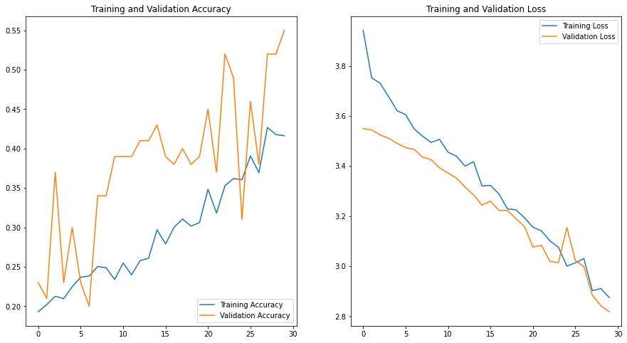

```python
history = conv3d_model_history
acc = history.history['accuracy']
val_acc = history.history['val_accuracy']

loss = history.history['loss']
val_loss = history.history['val_loss']

epochs_range = range(num_epochs)

plt.figure(figsize=(15, 8))
plt.subplot(1, 2, 1)
plt.plot(epochs_range, acc, label='Training Accuracy')
plt.plot(epochs_range, val_acc, label='Validation Accuracy')
plt.legend(loc='lower right')
plt.title('Training and Validation Accuracy')

plt.subplot(1, 2, 2)
plt.plot(epochs_range, loss, label='Training Loss')
plt.plot(epochs_range, val_loss, label='Validation Loss')
plt.legend(loc='upper right')
plt.title('Training and Validation Loss')
plt.show()
```

### Insights:

- Model Learning is having a lot of flucations
- Model parameters are just 0.3 Million
- This might be due to optimizer.
- But let us do a few more experiments before changing optimizer.
- Training Accuracy=41% & Validation Accuracy=55%
- Model is underfitting so let us try data augmentation

## Model 8: Conv3D + SGD + Data Augmentation

```python
reset_random_seeds()
batch_size=30
num_epochs=30
image_x_shape = 100
image_y_shape = 100


train_generator = generator(train_path, train_doc, batch_size,augment=True)
val_generator = generator(val_path, val_doc, batch_size,augment=True)

class convolution3D():
    def __init__(self):
        return None

    def model(self, batch_size):
        model = Sequential()

        model.add(Conv3D(8, kernel_size=(3, 3, 3),activation='relu', padding="same",input_shape=(10, 100, 100, 3)))
        model.add(MaxPooling3D(pool_size=(2, 2, 2)))
        model.add(BatchNormalization())

        model.add(Conv3D(16, kernel_size=(3, 3, 3),activation='relu', padding="same",
                         kernel_regularizer=regularizers.l2(0.01),
                        bias_regularizer=regularizers.l2(0.01)))
        model.add(MaxPooling3D(pool_size=(2, 2, 2)))
        model.add(BatchNormalization())

        model.add(Conv3D(32, kernel_size=(3, 3, 3),activation='relu', padding="same",
                         kernel_regularizer=regularizers.l2(0.01),
                        bias_regularizer=regularizers.l2(0.01)))
        model.add(MaxPooling3D(pool_size=(2, 2, 2)))
        model.add(BatchNormalization())


        model.add(Conv3D(32, kernel_size=(3, 3, 3),activation='relu', padding="same",
                         kernel_regularizer=regularizers.l2(0.01),
                        bias_regularizer=regularizers.l2(0.01)))
        model.add(MaxPooling3D(pool_size=(2, 2, 1),data_format='channels_first'))
        model.add(BatchNormalization())

        model.add(Conv3D(64, kernel_size=(3, 3, 3),activation='relu', padding="same",
                         kernel_regularizer=regularizers.l2(0.01),
                        bias_regularizer=regularizers.l2(0.01)))

        model.add(MaxPooling3D(pool_size=(2, 2, 1),data_format='channels_first'))
        model.add(BatchNormalization())

        model.add(Conv3D(128, kernel_size=(3, 3, 3),activation='relu', padding="same",
                         kernel_regularizer=regularizers.l2(0.01),
                        bias_regularizer=regularizers.l2(0.01)))
        model.add(MaxPooling3D(pool_size=(2, 2, 2),data_format='channels_first'))
        model.add(BatchNormalization())


        model.add(Dropout(0.25))
        model.add(Flatten())
        model.add(Dense(256,activation='relu'))
        model.add(Dropout(0.5))
        model.add(Dense(128,activation='relu'))
        model.add(Dropout(0.5))
        model.add(Dense(64,activation='relu'))
        model.add(Dropout(0.5))
        model.add(Dense(5, activation='softmax'))
        return model


obj = convolution3D()
conv3d_model = obj.model(batch_size)
conv3d_optimiser = optimizers.SGD() #write your optimizer

conv3d_model.compile(optimizer=conv3d_optimiser, loss='categorical_crossentropy', metrics=['accuracy'])
print (conv3d_model.summary())

model_name = 'model_init' + '_' + str(curr_dt_time).replace(' ','').replace(':','_') + '/'

if not os.path.exists(model_name):
    os.mkdir(model_name)

filepath = model_name + 'model_3d-{epoch:05d}-{loss:.5f}-{accuracy:.5f}-{val_loss:.5f}-{val_accuracy:.5f}.h5'

checkpoint = ModelCheckpoint(filepath, monitor='val_loss', verbose=1, save_best_only=False, save_weights_only=False, mode='auto', period=1)

callbacks_list = [reduceLR,checkpoint]

conv3d_model_history_sgd_aug = conv3d_model.fit(train_generator,
                                           steps_per_epoch=steps_per_epoch,
                                           epochs=num_epochs,
                                           verbose=1,
                                           callbacks=callbacks_list,
                                           validation_data=val_generator,
                                           validation_steps=validation_steps,
                                           class_weight=None,
                                           workers=1,
                                           initial_epoch=0)
```

```
Model: "sequential_7"
_________________________________________________________________
Layer (type)                 Output Shape              Param #
=================================================================
conv3d_6 (Conv3D)            (None, 10, 100, 100, 8)   656
_________________________________________________________________
max_pooling3d_6 (MaxPooling3 (None, 5, 50, 50, 8)      0
_________________________________________________________________
batch_normalization_24 (Batc (None, 5, 50, 50, 8)      32
_________________________________________________________________
conv3d_7 (Conv3D)            (None, 5, 50, 50, 16)     3472
_________________________________________________________________
max_pooling3d_7 (MaxPooling3 (None, 2, 25, 25, 16)     0
_________________________________________________________________
batch_normalization_25 (Batc (None, 2, 25, 25, 16)     64
_________________________________________________________________
conv3d_8 (Conv3D)            (None, 2, 25, 25, 32)     13856
_________________________________________________________________
max_pooling3d_8 (MaxPooling3 (None, 1, 12, 12, 32)     0
_________________________________________________________________
batch_normalization_26 (Batc (None, 1, 12, 12, 32)     128
_________________________________________________________________
conv3d_9 (Conv3D)            (None, 1, 12, 12, 32)     27680
_________________________________________________________________
max_pooling3d_9 (MaxPooling3 (None, 1, 6, 6, 32)       0
_________________________________________________________________
batch_normalization_27 (Batc (None, 1, 6, 6, 32)       128
_________________________________________________________________
conv3d_10 (Conv3D)           (None, 1, 6, 6, 64)       55360
_________________________________________________________________
max_pooling3d_10 (MaxPooling (None, 1, 3, 3, 64)       0
_________________________________________________________________
batch_normalization_28 (Batc (None, 1, 3, 3, 64)       256
_________________________________________________________________
conv3d_11 (Conv3D)           (None, 1, 3, 3, 128)      221312
_________________________________________________________________
max_pooling3d_11 (MaxPooling (None, 1, 1, 1, 64)       0
_________________________________________________________________
batch_normalization_29 (Batc (None, 1, 1, 1, 64)       256
_________________________________________________________________
```

[output cut: 74 more lines]

```
Epoch 00025: ReduceLROnPlateau reducing learning rate to 0.004999999888241291.

Epoch 00025: saving model to model_init_2021-03-0607_15_05.084969/model_3d-00025-3.00822-0.38084-3.01122-0.39500.h5

Epoch 00026: saving model to model_init_2021-03-0607_15_05.084969/model_3d-00026-2.96804-0.40422-2.88085-0.55500.h5

Epoch 00027: saving model to model_init_2021-03-0607_15_05.084969/model_3d-00027-2.95893-0.37179-2.93287-0.49000.h5

Epoch 00028: ReduceLROnPlateau reducing learning rate to 0.0024999999441206455.

Epoch 00028: saving model to model_init_2021-03-0607_15_05.084969/model_3d-00028-2.96206-0.37632-2.89667-0.50000.h5

Epoch 00029: saving model to model_init_2021-03-0607_15_05.084969/model_3d-00029-2.91110-0.40950-2.82305-0.56500.h5

Epoch 00030: saving model to model_init_2021-03-0607_15_05.084969/model_3d-00030-2.88214-0.42534-2.87417-0.51500.h5
```

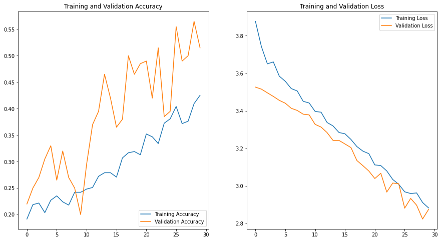

```python
history = conv3d_model_history_sgd_aug
acc = history.history['accuracy']
val_acc = history.history['val_accuracy']

loss = history.history['loss']
val_loss = history.history['val_loss']

epochs_range = range(num_epochs)

plt.figure(figsize=(15, 8))
plt.subplot(1, 2, 1)
plt.plot(epochs_range, acc, label='Training Accuracy')
plt.plot(epochs_range, val_acc, label='Validation Accuracy')
plt.legend(loc='lower right')
plt.title('Training and Validation Accuracy')

plt.subplot(1, 2, 2)
plt.plot(epochs_range, loss, label='Training Loss')
plt.plot(epochs_range, val_loss, label='Validation Loss')
plt.legend(loc='upper right')
plt.title('Training and Validation Loss')
plt.show()
```

## Model 9: Conv3D + SGD + Data Augmentation + Imagesize 160

```python
reset_random_seeds()
batch_size=30
num_epochs=30
image_x_shape = 160
image_y_shape = 160


train_generator = generator(train_path, train_doc, batch_size,augment=True)
val_generator = generator(val_path, val_doc, batch_size,augment=True)

class convolution3D():
    def __init__(self):
        return None

    def model(self, batch_size):
        model = Sequential()

        model.add(Conv3D(8, kernel_size=(3, 3, 3),activation='relu', padding="same",input_shape=(10, image_x_shape, image_y_shape, 3)))
        model.add(MaxPooling3D(pool_size=(2, 2, 2)))
        model.add(BatchNormalization())

        model.add(Conv3D(16, kernel_size=(3, 3, 3),activation='relu', padding="same",
                         kernel_regularizer=regularizers.l2(0.01),
                        bias_regularizer=regularizers.l2(0.01)))
        model.add(MaxPooling3D(pool_size=(2, 2, 2)))
        model.add(BatchNormalization())

        model.add(Conv3D(32, kernel_size=(3, 3, 3),activation='relu', padding="same",
                         kernel_regularizer=regularizers.l2(0.01),
                        bias_regularizer=regularizers.l2(0.01)))
        model.add(MaxPooling3D(pool_size=(2, 2, 2)))
        model.add(BatchNormalization())


        model.add(Conv3D(32, kernel_size=(3, 3, 3),activation='relu', padding="same",
                         kernel_regularizer=regularizers.l2(0.01),
                        bias_regularizer=regularizers.l2(0.01)))
        model.add(MaxPooling3D(pool_size=(2, 2, 1),data_format='channels_first'))
        model.add(BatchNormalization())

        model.add(Conv3D(64, kernel_size=(3, 3, 3),activation='relu', padding="same",
                         kernel_regularizer=regularizers.l2(0.01),
                        bias_regularizer=regularizers.l2(0.01)))

        model.add(MaxPooling3D(pool_size=(2, 2, 1),data_format='channels_first'))
        model.add(BatchNormalization())

        model.add(Conv3D(128, kernel_size=(3, 3, 3),activation='relu', padding="same",
                         kernel_regularizer=regularizers.l2(0.01),
                        bias_regularizer=regularizers.l2(0.01)))
        model.add(MaxPooling3D(pool_size=(2, 2, 2),data_format='channels_first'))
        model.add(BatchNormalization())


        model.add(Dropout(0.25))
        model.add(Flatten())
        model.add(Dense(256,activation='relu'))
        model.add(Dropout(0.5))
        model.add(Dense(128,activation='relu'))
        model.add(Dropout(0.5))
        model.add(Dense(64,activation='relu'))
        model.add(Dropout(0.5))
        model.add(Dense(5, activation='softmax'))
        return model


obj = convolution3D()
conv3d_model = obj.model(batch_size)
conv3d_optimiser = optimizers.SGD() #write your optimizer

conv3d_model.compile(optimizer=conv3d_optimiser, loss='categorical_crossentropy', metrics=['accuracy'])
print (conv3d_model.summary())

model_name = 'model_init' + '_' + str(curr_dt_time).replace(' ','').replace(':','_') + '/'

if not os.path.exists(model_name):
    os.mkdir(model_name)

filepath = model_name + 'model_3d-{epoch:05d}-{loss:.5f}-{accuracy:.5f}-{val_loss:.5f}-{val_accuracy:.5f}.h5'

checkpoint = ModelCheckpoint(filepath, monitor='val_loss', verbose=1, save_best_only=False, save_weights_only=False, mode='auto', period=1)

callbacks_list = [reduceLR,checkpoint]

if (num_train_sequences%batch_size) == 0:
    steps_per_epoch = int(num_train_sequences/batch_size)
else:
    steps_per_epoch = (num_train_sequences//batch_size) + 1

if (num_val_sequences%batch_size) == 0:
    validation_steps = int(num_val_sequences/batch_size)
else:
    validation_steps = (num_val_sequences//batch_size) + 1

conv3d_model_history_sgd_aug_160 = conv3d_model.fit(train_generator,
                                           steps_per_epoch=steps_per_epoch,
                                           epochs=num_epochs,
                                           verbose=1,
                                           callbacks=callbacks_list,
                                           validation_data=val_generator,
                                           validation_steps=validation_steps,
                                           class_weight=None,
                                           workers=1,
                                           initial_epoch=0)
```

```
Model: "sequential_8"
_________________________________________________________________
Layer (type)                 Output Shape              Param #
=================================================================
conv3d_12 (Conv3D)           (None, 10, 160, 160, 8)   656
_________________________________________________________________
max_pooling3d_12 (MaxPooling (None, 5, 80, 80, 8)      0
_________________________________________________________________
batch_normalization_30 (Batc (None, 5, 80, 80, 8)      32
_________________________________________________________________
conv3d_13 (Conv3D)           (None, 5, 80, 80, 16)     3472
_________________________________________________________________
max_pooling3d_13 (MaxPooling (None, 2, 40, 40, 16)     0
_________________________________________________________________
batch_normalization_31 (Batc (None, 2, 40, 40, 16)     64
_________________________________________________________________
conv3d_14 (Conv3D)           (None, 2, 40, 40, 32)     13856
_________________________________________________________________
max_pooling3d_14 (MaxPooling (None, 1, 20, 20, 32)     0
_________________________________________________________________
batch_normalization_32 (Batc (None, 1, 20, 20, 32)     128
_________________________________________________________________
conv3d_15 (Conv3D)           (None, 1, 20, 20, 32)     27680
_________________________________________________________________
max_pooling3d_15 (MaxPooling (None, 1, 10, 10, 32)     0
_________________________________________________________________
batch_normalization_33 (Batc (None, 1, 10, 10, 32)     128
_________________________________________________________________
conv3d_16 (Conv3D)           (None, 1, 10, 10, 64)     55360
_________________________________________________________________
max_pooling3d_16 (MaxPooling (None, 1, 5, 5, 64)       0
_________________________________________________________________
batch_normalization_34 (Batc (None, 1, 5, 5, 64)       256
_________________________________________________________________
conv3d_17 (Conv3D)           (None, 1, 5, 5, 128)      221312
_________________________________________________________________
max_pooling3d_17 (MaxPooling (None, 1, 2, 2, 64)       0
_________________________________________________________________
batch_normalization_35 (Batc (None, 1, 2, 2, 64)       256
_________________________________________________________________
```

[output cut: 74 more lines]

```
Epoch 00024: saving model to model_init_2021-03-0607_15_05.084969/model_3d-00024-2.90553-0.42760-2.79436-0.56000.h5

Epoch 00025: saving model to model_init_2021-03-0607_15_05.084969/model_3d-00025-2.90769-0.44646-2.77643-0.57500.h5

Epoch 00026: saving model to model_init_2021-03-0607_15_05.084969/model_3d-00026-2.84323-0.45852-2.82414-0.50000.h5

Epoch 00027: ReduceLROnPlateau reducing learning rate to 0.0024999999441206455.

Epoch 00027: saving model to model_init_2021-03-0607_15_05.084969/model_3d-00027-2.84743-0.45777-2.78263-0.48000.h5

Epoch 00028: saving model to model_init_2021-03-0607_15_05.084969/model_3d-00028-2.82395-0.48416-2.75114-0.54000.h5

Epoch 00029: saving model to model_init_2021-03-0607_15_05.084969/model_3d-00029-2.79810-0.46983-2.68540-0.57000.h5

Epoch 00030: saving model to model_init_2021-03-0607_15_05.084969/model_3d-00030-2.81872-0.47587-2.72860-0.54000.h5
```

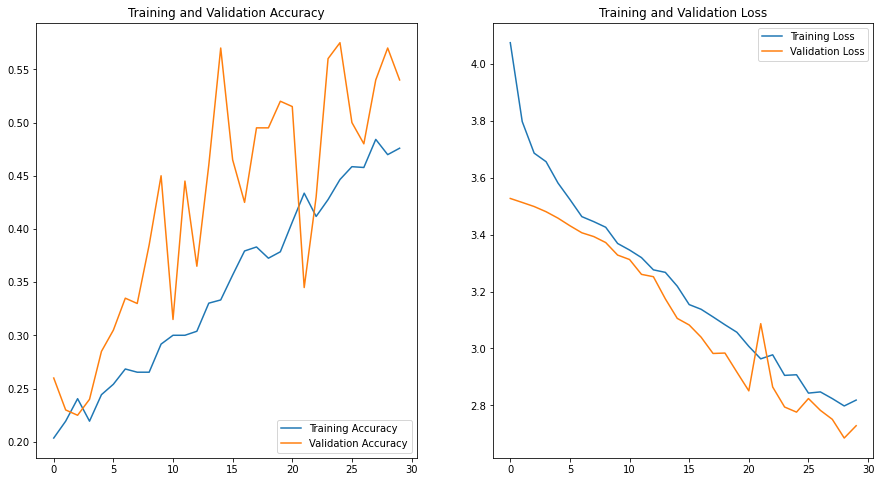

```python
history = conv3d_model_history_sgd_aug_160
acc = history.history['accuracy']
val_acc = history.history['val_accuracy']

loss = history.history['loss']
val_loss = history.history['val_loss']

epochs_range = range(num_epochs)

plt.figure(figsize=(15, 8))
plt.subplot(1, 2, 1)
plt.plot(epochs_range, acc, label='Training Accuracy')
plt.plot(epochs_range, val_acc, label='Validation Accuracy')
plt.legend(loc='lower right')
plt.title('Training and Validation Accuracy')

plt.subplot(1, 2, 2)
plt.plot(epochs_range, loss, label='Training Loss')
plt.plot(epochs_range, val_loss, label='Validation Loss')
plt.legend(loc='upper right')
plt.title('Training and Validation Loss')
plt.show()
```

### Insights:

- Model Learning is also having a lot of flucations
- Image size increase helped to rise accuracy a little bit
- Training Accuracy=49% & Validation Accuracy=54%
- Model is still underfitting
- Let us go ahead and change the optimizer to ADAM

## Model 10: Conv3D + ADAM Optimizer

```python
reset_random_seeds()
batch_size=30
num_epochs=30
image_x_shape = 100
image_y_shape = 100


train_generator = generator(train_path, train_doc, batch_size,augment=False)
val_generator = generator(val_path, val_doc, batch_size,augment=False)

class convolution3D():
    def __init__(self):
        return None

    def model(self, batch_size):
        model = Sequential()

        model.add(Conv3D(8, kernel_size=(3, 3, 3),activation='relu', padding="same",input_shape=(10, 100, 100, 3)))
        model.add(MaxPooling3D(pool_size=(2, 2, 2)))
        model.add(BatchNormalization())

        model.add(Conv3D(16, kernel_size=(3, 3, 3),activation='relu', padding="same",
                         kernel_regularizer=regularizers.l2(0.01),
                        bias_regularizer=regularizers.l2(0.01)))
        model.add(MaxPooling3D(pool_size=(2, 2, 2)))
        model.add(BatchNormalization())

        model.add(Conv3D(32, kernel_size=(3, 3, 3),activation='relu', padding="same",
                         kernel_regularizer=regularizers.l2(0.01),
                        bias_regularizer=regularizers.l2(0.01)))
        model.add(MaxPooling3D(pool_size=(2, 2, 2)))
        model.add(BatchNormalization())


        model.add(Conv3D(32, kernel_size=(3, 3, 3),activation='relu', padding="same",
                         kernel_regularizer=regularizers.l2(0.01),
                        bias_regularizer=regularizers.l2(0.01)))
        model.add(MaxPooling3D(pool_size=(2, 2, 1),data_format='channels_first'))
        model.add(BatchNormalization())

        model.add(Conv3D(64, kernel_size=(3, 3, 3),activation='relu', padding="same",
                         kernel_regularizer=regularizers.l2(0.01),
                        bias_regularizer=regularizers.l2(0.01)))

        model.add(MaxPooling3D(pool_size=(2, 2, 1),data_format='channels_first'))
        model.add(BatchNormalization())

        model.add(Conv3D(128, kernel_size=(3, 3, 3),activation='relu', padding="same",
                         kernel_regularizer=regularizers.l2(0.01),
                        bias_regularizer=regularizers.l2(0.01)))
        model.add(MaxPooling3D(pool_size=(2, 2, 2),data_format='channels_first'))
        model.add(BatchNormalization())


        model.add(Dropout(0.25))
        model.add(Flatten())
        model.add(Dense(256,activation='relu'))
        model.add(Dropout(0.5))
        model.add(Dense(128,activation='relu'))
        model.add(Dropout(0.5))
        model.add(Dense(64,activation='relu'))
        model.add(Dropout(0.5))
        model.add(Dense(5, activation='softmax'))
        return model


obj = convolution3D()
conv3d_model = obj.model(batch_size)
conv3d_optimiser = optimizers.Adam() #write your optimizer

conv3d_model.compile(optimizer=conv3d_optimiser, loss='categorical_crossentropy', metrics=['accuracy'])
print (conv3d_model.summary())

model_name = 'model_init' + '_' + str(curr_dt_time).replace(' ','').replace(':','_') + '/'

if not os.path.exists(model_name):
    os.mkdir(model_name)

filepath = model_name + 'model_3d-{epoch:05d}-{loss:.5f}-{accuracy:.5f}-{val_loss:.5f}-{val_accuracy:.5f}.h5'

checkpoint = ModelCheckpoint(filepath, monitor='val_loss', verbose=1, save_best_only=False, save_weights_only=False, mode='auto', period=1)

callbacks_list = [reduceLR,checkpoint]

if (num_train_sequences%batch_size) == 0:
    steps_per_epoch = int(num_train_sequences/batch_size)
else:
    steps_per_epoch = (num_train_sequences//batch_size) + 1

if (num_val_sequences%batch_size) == 0:
    validation_steps = int(num_val_sequences/batch_size)
else:
    validation_steps = (num_val_sequences//batch_size) + 1

conv3d_model_history_adam = conv3d_model.fit(train_generator,
                                           steps_per_epoch=steps_per_epoch,
                                           epochs=num_epochs,
                                           verbose=1,
                                           callbacks=callbacks_list,
                                           validation_data=val_generator,
                                           validation_steps=validation_steps,
                                           class_weight=None,
                                           workers=1,
                                           initial_epoch=0)
```

```
Model: "sequential_9"
_________________________________________________________________
Layer (type)                 Output Shape              Param #
=================================================================
conv3d_18 (Conv3D)           (None, 10, 100, 100, 8)   656
_________________________________________________________________
max_pooling3d_18 (MaxPooling (None, 5, 50, 50, 8)      0
_________________________________________________________________
batch_normalization_36 (Batc (None, 5, 50, 50, 8)      32
_________________________________________________________________
conv3d_19 (Conv3D)           (None, 5, 50, 50, 16)     3472
_________________________________________________________________
max_pooling3d_19 (MaxPooling (None, 2, 25, 25, 16)     0
_________________________________________________________________
batch_normalization_37 (Batc (None, 2, 25, 25, 16)     64
_________________________________________________________________
conv3d_20 (Conv3D)           (None, 2, 25, 25, 32)     13856
_________________________________________________________________
max_pooling3d_20 (MaxPooling (None, 1, 12, 12, 32)     0
_________________________________________________________________
batch_normalization_38 (Batc (None, 1, 12, 12, 32)     128
_________________________________________________________________
conv3d_21 (Conv3D)           (None, 1, 12, 12, 32)     27680
_________________________________________________________________
max_pooling3d_21 (MaxPooling (None, 1, 6, 6, 32)       0
_________________________________________________________________
batch_normalization_39 (Batc (None, 1, 6, 6, 32)       128
_________________________________________________________________
conv3d_22 (Conv3D)           (None, 1, 6, 6, 64)       55360
_________________________________________________________________
max_pooling3d_22 (MaxPooling (None, 1, 3, 3, 64)       0
_________________________________________________________________
batch_normalization_40 (Batc (None, 1, 3, 3, 64)       256
_________________________________________________________________
conv3d_23 (Conv3D)           (None, 1, 3, 3, 128)      221312
_________________________________________________________________
max_pooling3d_23 (MaxPooling (None, 1, 1, 1, 64)       0
_________________________________________________________________
batch_normalization_41 (Batc (None, 1, 1, 1, 64)       256
_________________________________________________________________
```

[output cut: 78 more lines]

```
Epoch 00025: saving model to model_init_2021-03-0607_15_05.084969/model_3d-00025-1.35965-0.75113-1.70578-0.64000.h5

Epoch 00026: ReduceLROnPlateau reducing learning rate to 0.0001250000059371814.

Epoch 00026: saving model to model_init_2021-03-0607_15_05.084969/model_3d-00026-1.44273-0.70437-1.87828-0.54000.h5

Epoch 00027: saving model to model_init_2021-03-0607_15_05.084969/model_3d-00027-1.38634-0.74811-1.70182-0.66000.h5

Epoch 00028: saving model to model_init_2021-03-0607_15_05.084969/model_3d-00028-1.35141-0.74510-1.54575-0.73000.h5

Epoch 00029: saving model to model_init_2021-03-0607_15_05.084969/model_3d-00029-1.28425-0.78130-1.58608-0.68000.h5

Epoch 00030: ReduceLROnPlateau reducing learning rate to 6.25000029685907e-05.

Epoch 00030: saving model to model_init_2021-03-0607_15_05.084969/model_3d-00030-1.24772-0.79789-1.59918-0.68000.h5
```

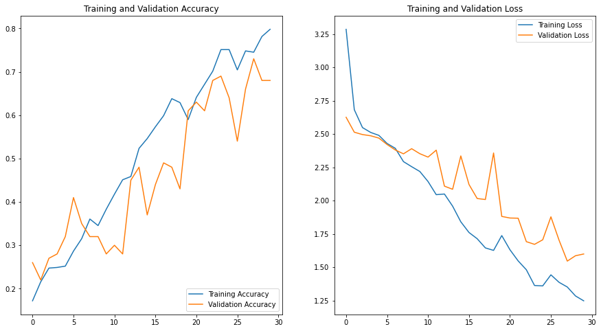

```python
history = conv3d_model_history_adam
acc = history.history['accuracy']
val_acc = history.history['val_accuracy']

loss = history.history['loss']
val_loss = history.history['val_loss']

epochs_range = range(num_epochs)

plt.figure(figsize=(15, 8))
plt.subplot(1, 2, 1)
plt.plot(epochs_range, acc, label='Training Accuracy')
plt.plot(epochs_range, val_acc, label='Validation Accuracy')
plt.legend(loc='lower right')
plt.title('Training and Validation Accuracy')

plt.subplot(1, 2, 2)
plt.plot(epochs_range, loss, label='Training Loss')
plt.plot(epochs_range, val_loss, label='Validation Loss')
plt.legend(loc='upper right')
plt.title('Training and Validation Loss')
plt.show()
```

## Model 11: Conv3D + ADAM + Data Augmentation

```python
reset_random_seeds()
batch_size=30
num_epochs=30
image_x_shape = 100
image_y_shape = 100


train_generator = generator(train_path, train_doc, batch_size,augment=True)
val_generator = generator(val_path, val_doc, batch_size,augment=True)

class convolution3D():
    def __init__(self):
        return None

    def model(self, batch_size):
        model = Sequential()

        model.add(Conv3D(8, kernel_size=(3, 3, 3),activation='relu', padding="same",input_shape=(10, 100, 100, 3)))
        model.add(MaxPooling3D(pool_size=(2, 2, 2)))
        model.add(BatchNormalization())

        model.add(Conv3D(16, kernel_size=(3, 3, 3),activation='relu', padding="same",
                         kernel_regularizer=regularizers.l2(0.01),
                        bias_regularizer=regularizers.l2(0.01)))
        model.add(MaxPooling3D(pool_size=(2, 2, 2)))
        model.add(BatchNormalization())

        model.add(Conv3D(32, kernel_size=(3, 3, 3),activation='relu', padding="same",
                         kernel_regularizer=regularizers.l2(0.01),
                        bias_regularizer=regularizers.l2(0.01)))
        model.add(MaxPooling3D(pool_size=(2, 2, 2)))
        model.add(BatchNormalization())


        model.add(Conv3D(32, kernel_size=(3, 3, 3),activation='relu', padding="same",
                         kernel_regularizer=regularizers.l2(0.01),
                        bias_regularizer=regularizers.l2(0.01)))
        model.add(MaxPooling3D(pool_size=(2, 2, 1),data_format='channels_first'))
        model.add(BatchNormalization())

        model.add(Conv3D(64, kernel_size=(3, 3, 3),activation='relu', padding="same",
                         kernel_regularizer=regularizers.l2(0.01),
                        bias_regularizer=regularizers.l2(0.01)))

        model.add(MaxPooling3D(pool_size=(2, 2, 1),data_format='channels_first'))
        model.add(BatchNormalization())

        model.add(Conv3D(128, kernel_size=(3, 3, 3),activation='relu', padding="same",
                         kernel_regularizer=regularizers.l2(0.01),
                        bias_regularizer=regularizers.l2(0.01)))
        model.add(MaxPooling3D(pool_size=(2, 2, 2),data_format='channels_first'))
        model.add(BatchNormalization())


        model.add(Dropout(0.25))
        model.add(Flatten())
        model.add(Dense(256,activation='relu'))
        model.add(Dropout(0.5))
        model.add(Dense(128,activation='relu'))
        model.add(Dropout(0.5))
        model.add(Dense(64,activation='relu'))
        model.add(Dropout(0.5))
        model.add(Dense(5, activation='softmax'))
        return model


obj = convolution3D()
conv3d_model = obj.model(batch_size)
conv3d_optimiser = optimizers.Adam() #write your optimizer

conv3d_model.compile(optimizer=conv3d_optimiser, loss='categorical_crossentropy', metrics=['accuracy'])
print (conv3d_model.summary())

model_name = 'model_init' + '_' + str(curr_dt_time).replace(' ','').replace(':','_') + '/'

if not os.path.exists(model_name):
    os.mkdir(model_name)

filepath = model_name + 'model_3d-{epoch:05d}-{loss:.5f}-{accuracy:.5f}-{val_loss:.5f}-{val_accuracy:.5f}.h5'

checkpoint = ModelCheckpoint(filepath, monitor='val_loss', verbose=1, save_best_only=False, save_weights_only=False, mode='auto', period=1)

callbacks_list = [reduceLR,checkpoint]

if (num_train_sequences%batch_size) == 0:
    steps_per_epoch = int(num_train_sequences/batch_size)
else:
    steps_per_epoch = (num_train_sequences//batch_size) + 1

if (num_val_sequences%batch_size) == 0:
    validation_steps = int(num_val_sequences/batch_size)
else:
    validation_steps = (num_val_sequences//batch_size) + 1

conv3d_model_history_adam_aug = conv3d_model.fit(train_generator,
                                           steps_per_epoch=steps_per_epoch,
                                           epochs=num_epochs,
                                           verbose=1,
                                           callbacks=callbacks_list,
                                           validation_data=val_generator,
                                           validation_steps=validation_steps,
                                           class_weight=None,
                                           workers=1,
                                           initial_epoch=0)
```

```
Model: "sequential_10"
_________________________________________________________________
Layer (type)                 Output Shape              Param #
=================================================================
conv3d_24 (Conv3D)           (None, 10, 100, 100, 8)   656
_________________________________________________________________
max_pooling3d_24 (MaxPooling (None, 5, 50, 50, 8)      0
_________________________________________________________________
batch_normalization_42 (Batc (None, 5, 50, 50, 8)      32
_________________________________________________________________
conv3d_25 (Conv3D)           (None, 5, 50, 50, 16)     3472
_________________________________________________________________
max_pooling3d_25 (MaxPooling (None, 2, 25, 25, 16)     0
_________________________________________________________________
batch_normalization_43 (Batc (None, 2, 25, 25, 16)     64
_________________________________________________________________
conv3d_26 (Conv3D)           (None, 2, 25, 25, 32)     13856
_________________________________________________________________
max_pooling3d_26 (MaxPooling (None, 1, 12, 12, 32)     0
_________________________________________________________________
batch_normalization_44 (Batc (None, 1, 12, 12, 32)     128
_________________________________________________________________
conv3d_27 (Conv3D)           (None, 1, 12, 12, 32)     27680
_________________________________________________________________
max_pooling3d_27 (MaxPooling (None, 1, 6, 6, 32)       0
_________________________________________________________________
batch_normalization_45 (Batc (None, 1, 6, 6, 32)       128
_________________________________________________________________
conv3d_28 (Conv3D)           (None, 1, 6, 6, 64)       55360
_________________________________________________________________
max_pooling3d_28 (MaxPooling (None, 1, 3, 3, 64)       0
_________________________________________________________________
batch_normalization_46 (Batc (None, 1, 3, 3, 64)       256
_________________________________________________________________
conv3d_29 (Conv3D)           (None, 1, 3, 3, 128)      221312
_________________________________________________________________
max_pooling3d_29 (MaxPooling (None, 1, 1, 1, 64)       0
_________________________________________________________________
batch_normalization_47 (Batc (None, 1, 1, 1, 64)       256
_________________________________________________________________
```

[output cut: 80 more lines]

```
Epoch 00025: saving model to model_init_2021-03-0607_15_05.084969/model_3d-00025-1.15972-0.80618-1.54894-0.65500.h5

Epoch 00026: saving model to model_init_2021-03-0607_15_05.084969/model_3d-00026-1.19745-0.78658-1.59412-0.68500.h5

Epoch 00027: ReduceLROnPlateau reducing learning rate to 6.25000029685907e-05.

Epoch 00027: saving model to model_init_2021-03-0607_15_05.084969/model_3d-00027-1.16067-0.81825-1.62931-0.70000.h5

Epoch 00028: saving model to model_init_2021-03-0607_15_05.084969/model_3d-00028-1.11747-0.81222-1.56257-0.69000.h5

Epoch 00029: ReduceLROnPlateau reducing learning rate to 3.125000148429535e-05.

Epoch 00029: saving model to model_init_2021-03-0607_15_05.084969/model_3d-00029-1.14180-0.80392-1.57598-0.69500.h5

Epoch 00030: saving model to model_init_2021-03-0607_15_05.084969/model_3d-00030-1.09253-0.80920-1.58262-0.66500.h5
```

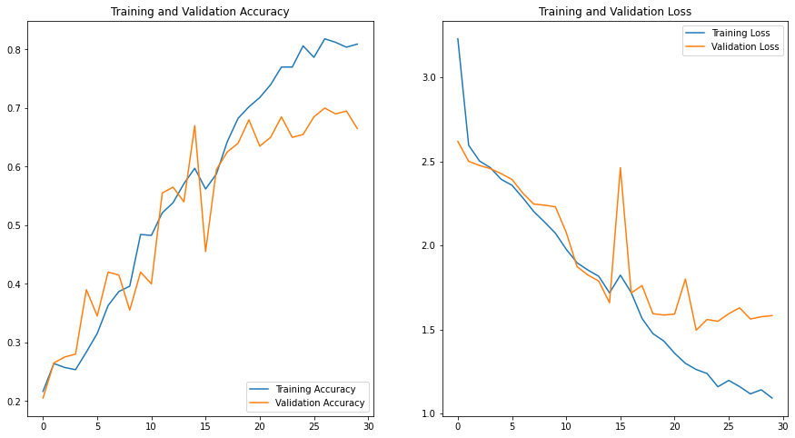

```python
history = conv3d_model_history_adam_aug
acc = history.history['accuracy']
val_acc = history.history['val_accuracy']

loss = history.history['loss']
val_loss = history.history['val_loss']

epochs_range = range(num_epochs)

plt.figure(figsize=(15, 8))
plt.subplot(1, 2, 1)
plt.plot(epochs_range, acc, label='Training Accuracy')
plt.plot(epochs_range, val_acc, label='Validation Accuracy')
plt.legend(loc='lower right')
plt.title('Training and Validation Accuracy')

plt.subplot(1, 2, 2)
plt.plot(epochs_range, loss, label='Training Loss')
plt.plot(epochs_range, val_loss, label='Validation Loss')
plt.legend(loc='upper right')
plt.title('Training and Validation Loss')
plt.show()
```

### Insights:

- Model is training properly
- Training Accuracy=82% & Validation Accuracy=70%
- Let us try increase image size to improve accuracy furthur

## Conv3D + ADAM + Data Augmentation (ImageSize=160)

```python
reset_random_seeds()
batch_size=30
num_epochs=30
image_x_shape = 160
image_y_shape = 160


train_generator = generator(train_path, train_doc, batch_size,augment=True)
val_generator = generator(val_path, val_doc, batch_size,augment=True)

class convolution3D():
    def __init__(self):
        return None

    def model(self, batch_size):
        model = Sequential()

        model.add(Conv3D(8, kernel_size=(3, 3, 3),activation='relu', padding="same",input_shape=(10, image_x_shape, image_y_shape, 3)))
        model.add(MaxPooling3D(pool_size=(2, 2, 2)))
        model.add(BatchNormalization())

        model.add(Conv3D(16, kernel_size=(3, 3, 3),activation='relu', padding="same",
                         kernel_regularizer=regularizers.l2(0.01),
                        bias_regularizer=regularizers.l2(0.01)))
        model.add(MaxPooling3D(pool_size=(2, 2, 2)))
        model.add(BatchNormalization())

        model.add(Conv3D(32, kernel_size=(3, 3, 3),activation='relu', padding="same",
                         kernel_regularizer=regularizers.l2(0.01),
                        bias_regularizer=regularizers.l2(0.01)))
        model.add(MaxPooling3D(pool_size=(2, 2, 2)))
        model.add(BatchNormalization())


        model.add(Conv3D(32, kernel_size=(3, 3, 3),activation='relu', padding="same",
                         kernel_regularizer=regularizers.l2(0.01),
                        bias_regularizer=regularizers.l2(0.01)))
        model.add(MaxPooling3D(pool_size=(2, 2, 1),data_format='channels_first'))
        model.add(BatchNormalization())

        model.add(Conv3D(64, kernel_size=(3, 3, 3),activation='relu', padding="same",
                         kernel_regularizer=regularizers.l2(0.01),
                        bias_regularizer=regularizers.l2(0.01)))

        model.add(MaxPooling3D(pool_size=(2, 2, 1),data_format='channels_first'))
        model.add(BatchNormalization())

        model.add(Conv3D(128, kernel_size=(3, 3, 3),activation='relu', padding="same",
                         kernel_regularizer=regularizers.l2(0.01),
                        bias_regularizer=regularizers.l2(0.01)))
        model.add(MaxPooling3D(pool_size=(2, 2, 2),data_format='channels_first'))
        model.add(BatchNormalization())


        model.add(Dropout(0.25))
        model.add(Flatten())
        model.add(Dense(256,activation='relu'))
        model.add(Dropout(0.5))
        model.add(Dense(128,activation='relu'))
        model.add(Dropout(0.5))
        model.add(Dense(64,activation='relu'))
        model.add(Dropout(0.5))
        model.add(Dense(5, activation='softmax'))
        return model


obj = convolution3D()
conv3d_model = obj.model(batch_size)
conv3d_optimiser = optimizers.Adam() #write your optimizer

conv3d_model.compile(optimizer=conv3d_optimiser, loss='categorical_crossentropy', metrics=['accuracy'])
print (conv3d_model.summary())

model_name = 'model_init' + '_' + str(curr_dt_time).replace(' ','').replace(':','_') + '/'

if not os.path.exists(model_name):
    os.mkdir(model_name)

filepath = model_name + 'model_3d-{epoch:05d}-{loss:.5f}-{accuracy:.5f}-{val_loss:.5f}-{val_accuracy:.5f}.h5'

checkpoint = ModelCheckpoint(filepath, monitor='val_loss', verbose=1, save_best_only=False, save_weights_only=False, mode='auto', period=1)

callbacks_list = [reduceLR,checkpoint]

if (num_train_sequences%batch_size) == 0:
    steps_per_epoch = int(num_train_sequences/batch_size)
else:
    steps_per_epoch = (num_train_sequences//batch_size) + 1

if (num_val_sequences%batch_size) == 0:
    validation_steps = int(num_val_sequences/batch_size)
else:
    validation_steps = (num_val_sequences//batch_size) + 1

conv3d_model_history_adam_aug_160 = conv3d_model.fit(train_generator,
                                           steps_per_epoch=steps_per_epoch,
                                           epochs=num_epochs,
                                           verbose=1,
                                           callbacks=callbacks_list,
                                           validation_data=val_generator,
                                           validation_steps=validation_steps,
                                           class_weight=None,
                                           workers=1,
                                           initial_epoch=0)
```

```
Model: "sequential_11"
_________________________________________________________________
Layer (type)                 Output Shape              Param #
=================================================================
conv3d_30 (Conv3D)           (None, 10, 160, 160, 8)   656
_________________________________________________________________
max_pooling3d_30 (MaxPooling (None, 5, 80, 80, 8)      0
_________________________________________________________________
batch_normalization_48 (Batc (None, 5, 80, 80, 8)      32
_________________________________________________________________
conv3d_31 (Conv3D)           (None, 5, 80, 80, 16)     3472
_________________________________________________________________
max_pooling3d_31 (MaxPooling (None, 2, 40, 40, 16)     0
_________________________________________________________________
batch_normalization_49 (Batc (None, 2, 40, 40, 16)     64
_________________________________________________________________
conv3d_32 (Conv3D)           (None, 2, 40, 40, 32)     13856
_________________________________________________________________
max_pooling3d_32 (MaxPooling (None, 1, 20, 20, 32)     0
_________________________________________________________________
batch_normalization_50 (Batc (None, 1, 20, 20, 32)     128
_________________________________________________________________
conv3d_33 (Conv3D)           (None, 1, 20, 20, 32)     27680
_________________________________________________________________
max_pooling3d_33 (MaxPooling (None, 1, 10, 10, 32)     0
_________________________________________________________________
batch_normalization_51 (Batc (None, 1, 10, 10, 32)     128
_________________________________________________________________
conv3d_34 (Conv3D)           (None, 1, 10, 10, 64)     55360
_________________________________________________________________
max_pooling3d_34 (MaxPooling (None, 1, 5, 5, 64)       0
_________________________________________________________________
batch_normalization_52 (Batc (None, 1, 5, 5, 64)       256
_________________________________________________________________
conv3d_35 (Conv3D)           (None, 1, 5, 5, 128)      221312
_________________________________________________________________
max_pooling3d_35 (MaxPooling (None, 1, 2, 2, 64)       0
_________________________________________________________________
batch_normalization_53 (Batc (None, 1, 2, 2, 64)       256
_________________________________________________________________
```

[output cut: 80 more lines]

```
Epoch 00025: ReduceLROnPlateau reducing learning rate to 6.25000029685907e-05.

Epoch 00025: saving model to model_init_2021-03-0607_15_05.084969/model_3d-00025-1.40351-0.69231-1.65057-0.61000.h5

Epoch 00026: saving model to model_init_2021-03-0607_15_05.084969/model_3d-00026-1.35140-0.70513-1.51390-0.67500.h5

Epoch 00027: saving model to model_init_2021-03-0607_15_05.084969/model_3d-00027-1.35295-0.70513-1.61487-0.63500.h5

Epoch 00028: ReduceLROnPlateau reducing learning rate to 3.125000148429535e-05.

Epoch 00028: saving model to model_init_2021-03-0607_15_05.084969/model_3d-00028-1.34127-0.71795-1.51971-0.66500.h5

Epoch 00029: saving model to model_init_2021-03-0607_15_05.084969/model_3d-00029-1.31022-0.72398-1.45172-0.72000.h5

Epoch 00030: saving model to model_init_2021-03-0607_15_05.084969/model_3d-00030-1.28636-0.73982-1.50783-0.66500.h5
```

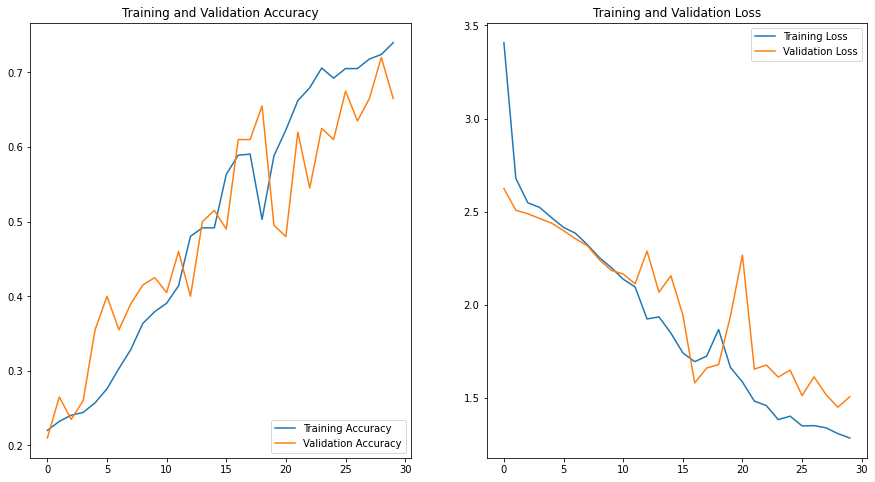

```python
history = conv3d_model_history_adam_aug_160
acc = history.history['accuracy']
val_acc = history.history['val_accuracy']

loss = history.history['loss']
val_loss = history.history['val_loss']

epochs_range = range(num_epochs)

plt.figure(figsize=(15, 8))
plt.subplot(1, 2, 1)
plt.plot(epochs_range, acc, label='Training Accuracy')
plt.plot(epochs_range, val_acc, label='Validation Accuracy')
plt.legend(loc='lower right')
plt.title('Training and Validation Accuracy')

plt.subplot(1, 2, 2)
plt.plot(epochs_range, loss, label='Training Loss')
plt.plot(epochs_range, val_loss, label='Validation Loss')
plt.legend(loc='upper right')
plt.title('Training and Validation Loss')
plt.show()
```

### Insights:

- Training Accuracy=70% & Validation Accuracy=72%
- Model can converge more if we try for more epochs maybe

## Conv3D + ADAM + Data Augmentation (ImageSize=160, Epochs=50)

```python
reset_random_seeds()
batch_size=30
num_epochs=50
image_x_shape = 160
image_y_shape = 160


train_generator = generator(train_path, train_doc, batch_size,augment=True)
val_generator = generator(val_path, val_doc, batch_size,augment=True)

class convolution3D():
    def __init__(self):
        return None

    def model(self, batch_size):
        model = Sequential()

        model.add(Conv3D(8, kernel_size=(3, 3, 3),activation='relu', padding="same",input_shape=(10, image_x_shape, image_y_shape, 3)))
        model.add(MaxPooling3D(pool_size=(2, 2, 2)))
        model.add(BatchNormalization())

        model.add(Conv3D(16, kernel_size=(3, 3, 3),activation='relu', padding="same",
                         kernel_regularizer=regularizers.l2(0.01),
                        bias_regularizer=regularizers.l2(0.01)))
        model.add(MaxPooling3D(pool_size=(2, 2, 2)))
        model.add(BatchNormalization())

        model.add(Conv3D(32, kernel_size=(3, 3, 3),activation='relu', padding="same",
                         kernel_regularizer=regularizers.l2(0.01),
                        bias_regularizer=regularizers.l2(0.01)))
        model.add(MaxPooling3D(pool_size=(2, 2, 2)))
        model.add(BatchNormalization())


        model.add(Conv3D(32, kernel_size=(3, 3, 3),activation='relu', padding="same",
                         kernel_regularizer=regularizers.l2(0.01),
                        bias_regularizer=regularizers.l2(0.01)))
        model.add(MaxPooling3D(pool_size=(2, 2, 1),data_format='channels_first'))
        model.add(BatchNormalization())

        model.add(Conv3D(64, kernel_size=(3, 3, 3),activation='relu', padding="same",
                         kernel_regularizer=regularizers.l2(0.01),
                        bias_regularizer=regularizers.l2(0.01)))

        model.add(MaxPooling3D(pool_size=(2, 2, 1),data_format='channels_first'))
        model.add(BatchNormalization())

        model.add(Conv3D(128, kernel_size=(3, 3, 3),activation='relu', padding="same",
                         kernel_regularizer=regularizers.l2(0.01),
                        bias_regularizer=regularizers.l2(0.01)))
        model.add(MaxPooling3D(pool_size=(2, 2, 2),data_format='channels_first'))
        model.add(BatchNormalization())


        model.add(Dropout(0.25))
        model.add(Flatten())
        model.add(Dense(256,activation='relu'))
        model.add(Dropout(0.5))
        model.add(Dense(128,activation='relu'))
        model.add(Dropout(0.5))
        model.add(Dense(64,activation='relu'))
        model.add(Dropout(0.5))
        model.add(Dense(5, activation='softmax'))
        return model


obj = convolution3D()
conv3d_model = obj.model(batch_size)
conv3d_optimiser = optimizers.Adam() #write your optimizer

conv3d_model.compile(optimizer=conv3d_optimiser, loss='categorical_crossentropy', metrics=['accuracy'])
print (conv3d_model.summary())

model_name = 'model_init' + '_' + str(curr_dt_time).replace(' ','').replace(':','_') + '/'

if not os.path.exists(model_name):
    os.mkdir(model_name)

filepath = model_name + 'model_3d-{epoch:05d}-{loss:.5f}-{accuracy:.5f}-{val_loss:.5f}-{val_accuracy:.5f}.h5'

checkpoint = ModelCheckpoint(filepath, monitor='val_loss', verbose=1, save_best_only=False, save_weights_only=False, mode='auto', period=1)

callbacks_list = [reduceLR,checkpoint]

if (num_train_sequences%batch_size) == 0:
    steps_per_epoch = int(num_train_sequences/batch_size)
else:
    steps_per_epoch = (num_train_sequences//batch_size) + 1

if (num_val_sequences%batch_size) == 0:
    validation_steps = int(num_val_sequences/batch_size)
else:
    validation_steps = (num_val_sequences//batch_size) + 1

conv3d_model_history_adam_aug_160_ep50 = conv3d_model.fit(train_generator,
                                           steps_per_epoch=steps_per_epoch,
                                           epochs=num_epochs,
                                           verbose=1,
                                           callbacks=callbacks_list,
                                           validation_data=val_generator,
                                           validation_steps=validation_steps,
                                           class_weight=None,
                                           workers=1,
                                           initial_epoch=0)
```

```
Model: "sequential_12"
_________________________________________________________________
Layer (type)                 Output Shape              Param #
=================================================================
conv3d_36 (Conv3D)           (None, 10, 160, 160, 8)   656
_________________________________________________________________
max_pooling3d_36 (MaxPooling (None, 5, 80, 80, 8)      0
_________________________________________________________________
batch_normalization_54 (Batc (None, 5, 80, 80, 8)      32
_________________________________________________________________
conv3d_37 (Conv3D)           (None, 5, 80, 80, 16)     3472
_________________________________________________________________
max_pooling3d_37 (MaxPooling (None, 2, 40, 40, 16)     0
_________________________________________________________________
batch_normalization_55 (Batc (None, 2, 40, 40, 16)     64
_________________________________________________________________
conv3d_38 (Conv3D)           (None, 2, 40, 40, 32)     13856
_________________________________________________________________
max_pooling3d_38 (MaxPooling (None, 1, 20, 20, 32)     0
_________________________________________________________________
batch_normalization_56 (Batc (None, 1, 20, 20, 32)     128
_________________________________________________________________
conv3d_39 (Conv3D)           (None, 1, 20, 20, 32)     27680
_________________________________________________________________
max_pooling3d_39 (MaxPooling (None, 1, 10, 10, 32)     0
_________________________________________________________________
batch_normalization_57 (Batc (None, 1, 10, 10, 32)     128
_________________________________________________________________
conv3d_40 (Conv3D)           (None, 1, 10, 10, 64)     55360
_________________________________________________________________
max_pooling3d_40 (MaxPooling (None, 1, 5, 5, 64)       0
_________________________________________________________________
batch_normalization_58 (Batc (None, 1, 5, 5, 64)       256
_________________________________________________________________
conv3d_41 (Conv3D)           (None, 1, 5, 5, 128)      221312
_________________________________________________________________
max_pooling3d_41 (MaxPooling (None, 1, 2, 2, 64)       0
_________________________________________________________________
batch_normalization_59 (Batc (None, 1, 2, 2, 64)       256
_________________________________________________________________
```

[output cut: 132 more lines]

```
Epoch 00045: saving model to model_init_2021-03-0607_15_05.084969/model_3d-00045-1.04102-0.81222-1.44653-0.72000.h5

Epoch 00046: saving model to model_init_2021-03-0607_15_05.084969/model_3d-00046-1.02843-0.81976-1.30950-0.72000.h5

Epoch 00047: saving model to model_init_2021-03-0607_15_05.084969/model_3d-00047-1.01645-0.83032-1.56627-0.67000.h5

Epoch 00048: ReduceLROnPlateau reducing learning rate to 9.765625463842298e-07.

Epoch 00048: saving model to model_init_2021-03-0607_15_05.084969/model_3d-00048-1.05196-0.80845-1.45355-0.69000.h5

Epoch 00049: saving model to model_init_2021-03-0607_15_05.084969/model_3d-00049-1.06404-0.80015-1.41966-0.72500.h5

Epoch 00050: ReduceLROnPlateau reducing learning rate to 4.882812731921149e-07.

Epoch 00050: saving model to model_init_2021-03-0607_15_05.084969/model_3d-00050-1.02796-0.81674-1.33190-0.73000.h5
```

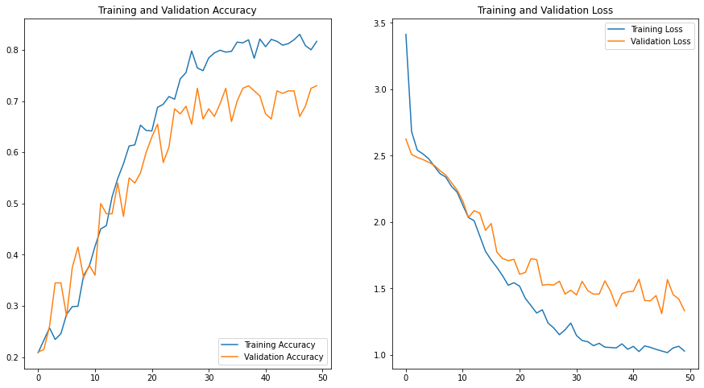

```python
history = conv3d_model_history_adam_aug_160_ep50
acc = history.history['accuracy']
val_acc = history.history['val_accuracy']

loss = history.history['loss']
val_loss = history.history['val_loss']

epochs_range = range(num_epochs)

plt.figure(figsize=(15, 8))
plt.subplot(1, 2, 1)
plt.plot(epochs_range, acc, label='Training Accuracy')
plt.plot(epochs_range, val_acc, label='Validation Accuracy')
plt.legend(loc='lower right')
plt.title('Training and Validation Accuracy')

plt.subplot(1, 2, 2)
plt.plot(epochs_range, loss, label='Training Loss')
plt.plot(epochs_range, val_loss, label='Validation Loss')
plt.legend(loc='upper right')
plt.title('Training and Validation Loss')
plt.show()
```

### Insights:

- Training Accuracy=82% & Validation Accuracy=73%
- This is our best and final model
- Parameters are just 0.4 Million
- We achieved similar accuracy as that of 5 Million parameters Model is just 0.4 Million Parameters

## Write Up Document and Conclusion

[output not shown]